# Ficha de Información Metropolitana

Universidad Autónoma Metropolitnana

Lic. Martínez Rodriguez, Alvaro[^1]

Lic. Pérez Victorino, Leonardo[^2]

La ficha de información metropolitana es una herramienta valiosa para la planificación territorial en zonas metropolitanas (ZM). Proporciona información censal en diferentes formatos, como gráficos, tablas y mapas, tanto de los Censos de Población y Vivienda, 2020 (CPV2020) como de los Censos Económicos de 1999, 2004, 2009, 2014 y 2019. Ambos publicados por el Instituto Nacional de Estadística y Geografía (INEGI).

## Información general de la Zona Metropolitana de Zacatecas-Guadalupe

Según (Sedatu 2018), la zona metropolitana se define como un área urbana que consta de una ciudad principal y su zona conurbada. Las zonas metropolitanas se caracterizan por tener una alta densidad de población y estar interconectadas por vías de transporte y comunicación. La zona metropolitana de Zacatecas-Guadalupe, se localiza en Zacatecas. y esta compuesta por 5 municipios, que se muestran a continuación:

| Nombre | Clave |
| --- | --- |
| Guadalupe | 32017 |
| Morelos | 32032 |
| Vetagrande | 32050 |
| Zacatecas | 32056 |
| Trancoso | 32057 |

Municipios de la zona metropolitana

Además, se presenta un mapa de la zona metropolitana:

[interactive chart not shown]

A continuación se presentan algunos datos generales sobre esta zona:

- Zona Metropolitana:Zacatecas-Guadalupe
- Número de municipios: 5
- Población total: 405,285
- Superficie de la ZM: 1,800.78 [m^2]
- Densidad poblacional: 225.061 [1/m^2] Hab/Km^2.
- Grado promedio de escolaridad: 9.986

## Información sociodemográfica

La estructura de población de la zona metropolitana de Zacatecas-Guadalupe se presenta en la una piramide poblacional ya que permite obtener una visión general de la distribución de la población por género y edad:

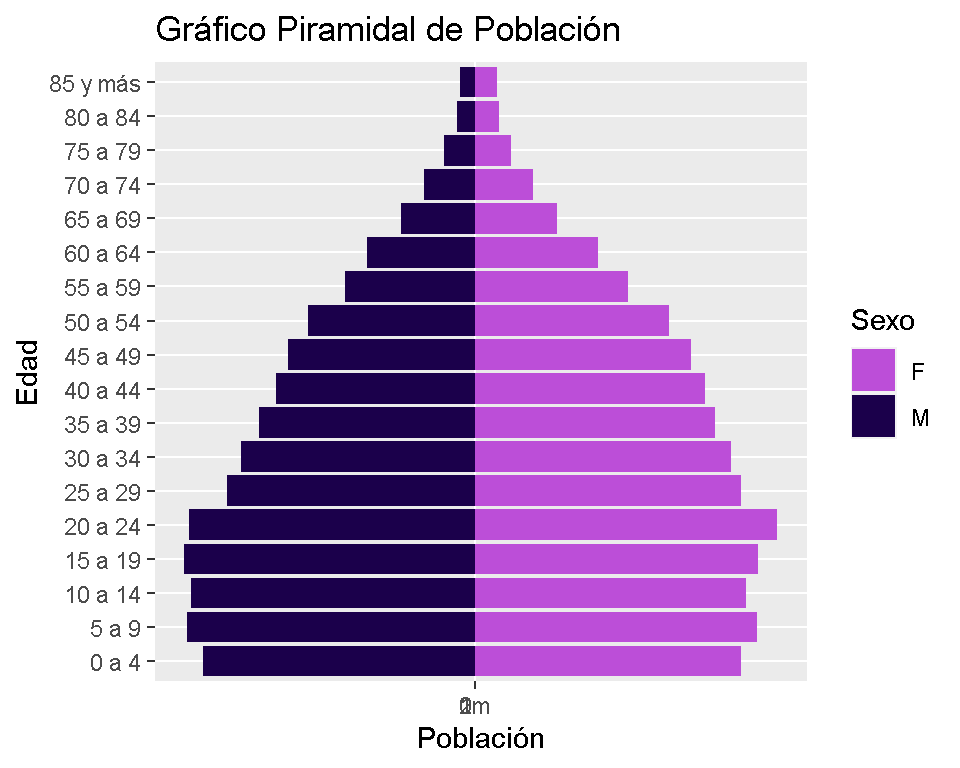

En el siguiente mapa se observa como se distribuye la población sobre la región:

[interactive chart not shown]

### Vivienda

El CPV 2020 también proporciona información sobre la vivienda en la zona metropolitana, a continuación se presentan los principales resultados:

### Socioeconómicos

La población en terminos de la poblacioón economicamente activa esta descrita por:

- Porcentaje de población de 12 años y más económicamente activa: 48%
- Porcentaje de población de 12 años y más no económicamente activa: 31% `

### Educación

La educación de la zona metropolitana esta caracterizada por los siguientes estadísticos:

- Porcentaje de población de 15 años y más sin escolaridad:2%
- Porcentaje de población de 15 años y más con al menos un grado aprobado en primaria: 69%
- Porcentaje de población de 15 años y más con educación básica completa: 18%
- Porcentaje de población de 15 años y más con secundaria o equivalente incompleta:2%
- Porcentaje de población de 18 años y más con al menos un grado aprobado en educación media superior: 39%

### Salud

La situación de la afiliación a algún servico de salud es la siguiente:

- Porcentaje de población afiliada a servicios de salud: 83%
- Población sin afiliación a servicios de salud:67699

### Indicadores de desarrollo

Finalmente se presentan tres indicadores de desarrollo; los índices son: índice de Desarrollo Humano (IDH), Índice de Marginación (IM) e Índice de Rezago Social (IRS).

IDH es un indicador elaborado por el Programa de Naciones Unidas para el Desarrollo (PNUD), este busca medir la calidad de vida, así como el progreso socioeconómico de cada entidad y municipio; El cálculo del Índice de Desarrollo Humano se realiza a partir de las tres variables: esperanza de vida, educación e ingreso per cápita.

- Muy Alto - IDH mayor de 1.
- Alto - IDH entre 0.80 a 1.
- Medio - IDH entre 0.50 y 0.80.
- Bajo - IDH entre 0 y 0.50
- Muy Bajo - IDH menores a 0.
- El promedio del IDH en 2020 para la zona metropolitana es de 0.76 según datos del PNUD.

El IM es un índice construido por el consejo Nacional de Población (CONAPO). Este índice considera 4 dimensiones estructurales para su construcción: vivienda, ingreso, educación y distribución de la población. El indice se puede ubicar en 5 estratos designados por la ténica de estratificación de Dalenius-Hodges..

Por último, el IRS es construido por el Consejo Nacional de Evaluación de la Política de Desarrollo Social, CONEVAL, este índice incorpora indicadores de educación, de acceso a servicios de salud, de servicios básicos y tiene como finalidad ordenar los municipios según sus carencias sociales. Este índice, al igual que el IM, se clasifica en cinco estratos.

## Datos económicos.

Con base en la información de los subsectores de los 21 sectores principales de la clasificación del SCIAN, extraída de los Censos Económicos del INEGI durante el periodo de 1998-2018, se ha llevado a cabo la agrupación de los datos de cada municipio que pertenece a una zona metropolitana en cinco grandes sectores: Primarios, Construcción, Manufactura, Comercio y Servicios. Esta clasificación se basa en la metodología proporcionada por el INEGI. Se utilizaron las siguientes variables:

- Unidades económicas (UE) [número de unidades]
- Activiso fijos totales (AF) [miles de pesos a precios corrientes]
- Formación bruta de capital fijo (FB) [miles de pesos a precios corrientes]
- Producción bruta total (PB) [miles de pesos a precios corrientes]
- Personal ocupado total (PO) [número de personas]
- Total de remuneraciones (RE) [miles de pesos a precios corrientes]
- Valor agregado censal bruto (VA) [miles de pesos a precios corrientes]

Posteriormente, se replica la metodología utilizada por García y Carranco (2008) para estimar los coeficientes de participación relativa (PR), de localización de la actividad económica (QL), Hirschman-Herfindahl (HH) e Inverso de Hirschman-Herfindahl (IHH).

$PR_ij$=$X_ij/X_in$

$QL_ij$=$(X_ij⁄X_j )/(X_in⁄X_n)$

$HH_ij$=$X_ij/X_in - X_j/X_n$

$IHH_ij$=$1/(X_ij/X_in - X_j/X_n)$

Donde:

- $X_ij$= Variable económica del sector i en el municipio j
- $X_j$= Variable económica del total de los sectores en el municipio j
- $X_in$= Variable económica del sector i de la Zona Metropolitana del municipio j
- $X_n$= Variable económica del total de los sectores de la Zona Metropolitana del municipio j

### Cifras brutas

#### 1999

##### UE

| Clave | Municipio | Primarios | Construcción | Manufactura | Comercio | Servicios |
| --- | --- | --- | --- | --- | --- | --- |
| 32017 | Guadalupe | 0 | 0 | 399 | 1,762 | 1,127 |
| 32032 | Morelos | 0 | 0 | 20 | 142 | 68 |
| 32050 | Vetagrande | 6 | 0 | 4 | 46 | 11 |
| 32056 | Zacatecas | 0 | 58 | 470 | 3,193 | 2,505 |
| 32057 | Trancoso | 0 | 0 | 0 | 0 | 0 |

##### AF

| Clave | Municipio | Primarios | Construcción | Manufactura | Comercio | Servicios |
| --- | --- | --- | --- | --- | --- | --- |
| 32017 | Guadalupe | 14,321 | 138,641 | 95,077 | 193,292 | 407,315 |
| 32032 | Morelos | 220 | 1,355 | 5,761 | 16,352 | 32,222 |
| 32050 | Vetagrande | 12,083 | 0 | 719 | 777 | 9,702 |
| 32056 | Zacatecas | 120,808 | 46,376 | 149,654 | 322,255 | 2,902,747 |
| 32057 | Trancoso | 0 | 0 | 0 | 0 | 0 |

##### FB

| Clave | Municipio | Primarios | Construcción | Manufactura | Comercio | Servicios |
| --- | --- | --- | --- | --- | --- | --- |
| 32017 | Guadalupe | 26 | 4,203 | 5,786 | 14,003 | 78,883 |
| 32032 | Morelos | 0 | 101 | 664 | 445 | 7,905 |
| 32050 | Vetagrande | 389 | 0 | 100 | 53 | 2,793 |
| 32056 | Zacatecas | 57,069 | 4,132 | 12,177 | 12,315 | 105,407 |
| 32057 | Trancoso | 0 | 0 | 0 | 0 | 0 |

##### PB

| Clave | Municipio | Primarios | Construcción | Manufactura | Comercio | Servicios |
| --- | --- | --- | --- | --- | --- | --- |
| 32017 | Guadalupe | 16,967 | 132,464 | 333,497 | 292,743 | 260,630 |
| 32032 | Morelos | 0 | 4,102 | 29,279 | 14,302 | 53,874 |
| 32050 | Vetagrande | 20,559 | 0 | 1,339 | 683 | 8,124 |
| 32056 | Zacatecas | 128,451 | 115,332 | 319,507 | 724,961 | 997,231 |
| 32057 | Trancoso | 0 | 0 | 0 | 0 | 0 |

##### PO

| Clave | Municipio | Primarios | Construcción | Manufactura | Comercio | Servicios |
| --- | --- | --- | --- | --- | --- | --- |
| 32017 | Guadalupe | 49 | 1,879 | 3,156 | 4,010 | 4,167 |
| 32032 | Morelos | 5 | 17 | 325 | 265 | 295 |
| 32050 | Vetagrande | 127 | 0 | 17 | 60 | 57 |
| 32056 | Zacatecas | 560 | 1,540 | 3,099 | 8,847 | 11,312 |
| 32057 | Trancoso | 0 | 0 | 0 | 0 | 0 |

##### RE

| Clave | Municipio | Primarios | Construcción | Manufactura | Comercio | Servicios |
| --- | --- | --- | --- | --- | --- | --- |
| 32017 | Guadalupe | 1,463 | 22,895 | 60,781 | 61,340 | 55,390 |
| 32032 | Morelos | 99 | 160 | 4,965 | 2,723 | 16,803 |
| 32050 | Vetagrande | 2,978 | 0 | 53 | 41 | 454 |
| 32056 | Zacatecas | 22,092 | 19,353 | 74,552 | 162,501 | 220,357 |
| 32057 | Trancoso | 0 | 0 | 0 | 0 | 0 |

##### VA

| Clave | Municipio | Primarios | Construcción | Manufactura | Comercio | Servicios |
| --- | --- | --- | --- | --- | --- | --- |
| 32017 | Guadalupe | 4,684 | 34,370 | 99,043 | 200,691 | 154,581 |
| 32032 | Morelos | -226 | 436 | 8,769 | 9,418 | 32,051 |
| 32050 | Vetagrande | 5,431 | 0 | 231 | 505 | 4,506 |
| 32056 | Zacatecas | 42,161 | 30,237 | 149,596 | 546,457 | 564,122 |
| 32057 | Trancoso | 0 | 0 | 0 | 0 | 0 |

#### 2004

##### UE

| Clave | Municipio | Primarios | Construcción | Manufactura | Comercio | Servicios |
| --- | --- | --- | --- | --- | --- | --- |
| 32017 | Guadalupe | 0 | 29 | 349 | 2,018 | 1,217 |
| 32032 | Morelos | 0 | 0 | 19 | 183 | 70 |
| 32050 | Vetagrande | 0 | 0 | 5 | 61 | 6 |
| 32056 | Zacatecas | 0 | 65 | 409 | 3,509 | 2,371 |
| 32057 | Trancoso | 0 | 0 | 20 | 226 | 20 |

##### AF

| Clave | Municipio | Primarios | Construcción | Manufactura | Comercio | Servicios |
| --- | --- | --- | --- | --- | --- | --- |
| 32017 | Guadalupe | 15,307 | 92,171 | 206,777 | 390,919 | 798,577 |
| 32032 | Morelos | 796,878 | 9,148 | 21,180 | 16,112 | 289,508 |
| 32050 | Vetagrande | 17,175 | 0 | 1,293 | 2,199 | 47,206 |
| 32056 | Zacatecas | 20,143 | 211,814 | 521,283 | 536,319 | 2,059,868 |
| 32057 | Trancoso | 0 | 0 | 2,021 | 16,741 | 9,720 |

##### FB

| Clave | Municipio | Primarios | Construcción | Manufactura | Comercio | Servicios |
| --- | --- | --- | --- | --- | --- | --- |
| 32017 | Guadalupe | 0 | 5,182 | 3,109 | 36,568 | 31,558 |
| 32032 | Morelos | 33,429 | 640 | -1,568 | -280 | 11,292 |
| 32050 | Vetagrande | 278 | 0 | 78 | 93 | 2,813 |
| 32056 | Zacatecas | 181 | 2,972 | 8,309 | 27,162 | 41,734 |
| 32057 | Trancoso | 0 | 0 | 6 | 209 | 1,524 |

##### PB

| Clave | Municipio | Primarios | Construcción | Manufactura | Comercio | Servicios |
| --- | --- | --- | --- | --- | --- | --- |
| 32017 | Guadalupe | 8,349 | 265,686 | 719,414 | 917,322 | 680,119 |
| 32032 | Morelos | 726,112 | 60,291 | 29,955 | 30,873 | 107,349 |
| 32050 | Vetagrande | 28,756 | 0 | 1,692 | 1,988 | 41,633 |
| 32056 | Zacatecas | 4,770 | 666,769 | 639,777 | 1,388,273 | 1,594,926 |
| 32057 | Trancoso | 0 | 0 | 7,006 | 32,360 | 17,061 |

##### PO

| Clave | Municipio | Primarios | Construcción | Manufactura | Comercio | Servicios |
| --- | --- | --- | --- | --- | --- | --- |
| 32017 | Guadalupe | 26 | 1,219 | 3,527 | 6,026 | 5,204 |
| 32032 | Morelos | 565 | 53 | 285 | 380 | 442 |
| 32050 | Vetagrande | 133 | 0 | 23 | 92 | 139 |
| 32056 | Zacatecas | 106 | 2,971 | 2,019 | 11,396 | 12,511 |
| 32057 | Trancoso | 0 | 0 | 66 | 455 | 161 |

##### RE

| Clave | Municipio | Primarios | Construcción | Manufactura | Comercio | Servicios |
| --- | --- | --- | --- | --- | --- | --- |
| 32017 | Guadalupe | 717 | 34,572 | 140,406 | 156,380 | 168,109 |
| 32032 | Morelos | 45,187 | 4,644 | 9,659 | 7,567 | 20,556 |
| 32050 | Vetagrande | 958 | 0 | 302 | 104 | 1,432 |
| 32056 | Zacatecas | 1,155 | 73,206 | 136,869 | 270,019 | 354,366 |
| 32057 | Trancoso | 0 | 0 | 177 | 678 | 807 |

##### VA

| Clave | Municipio | Primarios | Construcción | Manufactura | Comercio | Servicios |
| --- | --- | --- | --- | --- | --- | --- |
| 32017 | Guadalupe | 1,765 | 71,991 | 361,609 | 578,416 | 414,350 |
| 32032 | Morelos | 436,707 | 24,213 | 17,194 | 23,374 | 48,551 |
| 32050 | Vetagrande | 9,427 | 0 | 695 | 1,618 | 28,442 |
| 32056 | Zacatecas | 3,223 | 222,233 | 269,193 | 1,014,302 | 867,505 |
| 32057 | Trancoso | 0 | 0 | 3,395 | 28,706 | 8,243 |

#### 2009

##### UE

| Clave | Municipio | Primarios | Construcción | Manufactura | Comercio | Servicios |
| --- | --- | --- | --- | --- | --- | --- |
| 32017 | Guadalupe | 0 | 93 | 582 | 2,495 | 2,059 |
| 32032 | Morelos | 0 | 0 | 38 | 191 | 89 |
| 32050 | Vetagrande | 0 | 0 | 5 | 0 | 6 |
| 32056 | Zacatecas | 0 | 78 | 529 | 3,201 | 2,860 |
| 32057 | Trancoso | 0 | 0 | 34 | 272 | 117 |

##### AF

| Clave | Municipio | Primarios | Construcción | Manufactura | Comercio | Servicios |
| --- | --- | --- | --- | --- | --- | --- |
| 32017 | Guadalupe | 175 | 383,865 | 1,025,307 | 1,085,997 | 1,479,134 |
| 32032 | Morelos | 704,955 | 278 | 12,451 | 39,663 | 330,526 |
| 32050 | Vetagrande | 41,685 | 0 | 1,862 | 3,697 | 73,368 |
| 32056 | Zacatecas | 12,829 | 494,722 | 284,005 | 2,037,938 | 1,842,375 |
| 32057 | Trancoso | 0 | 906 | 6,279 | 35,089 | 26,447 |

##### FB

| Clave | Municipio | Primarios | Construcción | Manufactura | Comercio | Servicios |
| --- | --- | --- | --- | --- | --- | --- |
| 32017 | Guadalupe | 10 | 33,627 | 313,914 | 96,150 | 139,481 |
| 32032 | Morelos | -3,251 | 0 | 52 | 3,935 | 16,837 |
| 32050 | Vetagrande | 3,937 | 0 | 0 | 71 | 1,187 |
| 32056 | Zacatecas | 193 | 102,331 | 8,929 | 86,286 | 85,961 |
| 32057 | Trancoso | 0 | 0 | 264 | 610 | 3,187 |

##### PB

| Clave | Municipio | Primarios | Construcción | Manufactura | Comercio | Servicios |
| --- | --- | --- | --- | --- | --- | --- |
| 32017 | Guadalupe | 74 | 963,899 | 1,377,540 | 1,966,713 | 1,840,215 |
| 32032 | Morelos | 1,331,247 | 2,187 | 27,138 | 55,994 | 120,484 |
| 32050 | Vetagrande | 23,629 | 0 | 4,072 | 7,787 | 84,484 |
| 32056 | Zacatecas | 12,165 | 1,702,797 | 724,022 | 1,568,838 | 2,132,110 |
| 32057 | Trancoso | 0 | 4,363 | 10,599 | 22,570 | 25,447 |

##### PO

| Clave | Municipio | Primarios | Construcción | Manufactura | Comercio | Servicios |
| --- | --- | --- | --- | --- | --- | --- |
| 32017 | Guadalupe | 7 | 2,379 | 4,191 | 9,133 | 8,933 |
| 32032 | Morelos | 442 | 14 | 335 | 515 | 467 |
| 32050 | Vetagrande | 105 | 0 | 34 | 157 | 164 |
| 32056 | Zacatecas | 85 | 3,216 | 2,824 | 11,722 | 15,113 |
| 32057 | Trancoso | 0 | 40 | 113 | 594 | 368 |

##### RE

| Clave | Municipio | Primarios | Construcción | Manufactura | Comercio | Servicios |
| --- | --- | --- | --- | --- | --- | --- |
| 32017 | Guadalupe | 154 | 104,119 | 180,917 | 286,536 | 328,223 |
| 32032 | Morelos | 51,642 | 548 | 8,460 | 10,217 | 27,997 |
| 32050 | Vetagrande | 2,776 | 0 | 957 | 130 | 7,143 |
| 32056 | Zacatecas | 1,638 | 160,704 | 133,523 | 294,344 | 463,558 |
| 32057 | Trancoso | 0 | 1,708 | 1,493 | 1,500 | 6,784 |

##### VA

| Clave | Municipio | Primarios | Construcción | Manufactura | Comercio | Servicios |
| --- | --- | --- | --- | --- | --- | --- |
| 32017 | Guadalupe | -54 | 371,444 | 492,991 | 1,309,772 | 873,436 |
| 32032 | Morelos | 449,542 | 595 | 12,798 | 36,736 | 68,743 |
| 32050 | Vetagrande | 3,333 | 0 | 2,662 | 6,648 | 69,021 |
| 32056 | Zacatecas | 7,736 | 397,393 | 186,590 | 755,913 | 1,137,724 |
| 32057 | Trancoso | 0 | 2,453 | 4,006 | 12,440 | 13,631 |

#### 2014

##### UE

| Clave | Municipio | Primarios | Construcción | Manufactura | Comercio | Servicios |
| --- | --- | --- | --- | --- | --- | --- |
| 32017 | Guadalupe | 0 | 78 | 575 | 2,692 | 2,155 |
| 32032 | Morelos | 0 | 0 | 41 | 228 | 80 |
| 32050 | Vetagrande | 0 | 0 | 10 | 71 | 22 |
| 32056 | Zacatecas | 0 | 89 | 570 | 3,293 | 3,004 |
| 32057 | Trancoso | 0 | 0 | 54 | 291 | 83 |

##### AF

| Clave | Municipio | Primarios | Construcción | Manufactura | Comercio | Servicios |
| --- | --- | --- | --- | --- | --- | --- |
| 32017 | Guadalupe | 0 | 254,486 | 4,272,679 | 1,412,737 | 909,332 |
| 32032 | Morelos | 0 | 0 | 64,469 | 30,425 | 23,385 |
| 32050 | Vetagrande | 0 | 0 | 1,278 | 4,099 | 1,203 |
| 32056 | Zacatecas | 0 | 475,286 | 232,738 | 1,243,249 | 2,293,094 |
| 32057 | Trancoso | 0 | 0 | 7,291 | 30,344 | 6,108 |

##### FB

| Clave | Municipio | Primarios | Construcción | Manufactura | Comercio | Servicios |
| --- | --- | --- | --- | --- | --- | --- |
| 32017 | Guadalupe | 0 | 10,686 | 853,223 | 68,380 | 68,401 |
| 32032 | Morelos | 0 | 0 | 13,261 | 2,614 | 459 |
| 32050 | Vetagrande | 0 | 0 | 23 | 200 | 24 |
| 32056 | Zacatecas | 0 | 32,487 | 6,805 | 73,586 | 70,200 |
| 32057 | Trancoso | 0 | 0 | 137 | 877 | 933 |

##### PB

| Clave | Municipio | Primarios | Construcción | Manufactura | Comercio | Servicios |
| --- | --- | --- | --- | --- | --- | --- |
| 32017 | Guadalupe | 0 | 627,982 | 3,521,952 | 2,130,215 | 1,370,715 |
| 32032 | Morelos | 0 | 0 | 142,396 | 49,502 | 93,624 |
| 32050 | Vetagrande | 0 | 0 | 2,416 | 2,798 | 1,027 |
| 32056 | Zacatecas | 0 | 1,246,416 | 426,974 | 3,585,958 | 2,473,521 |
| 32057 | Trancoso | 0 | 0 | 13,264 | 20,904 | 8,484 |

##### PO

| Clave | Municipio | Primarios | Construcción | Manufactura | Comercio | Servicios |
| --- | --- | --- | --- | --- | --- | --- |
| 32017 | Guadalupe | 0 | 1,679 | 6,294 | 9,259 | 8,094 |
| 32032 | Morelos | 0 | 0 | 208 | 456 | 238 |
| 32050 | Vetagrande | 0 | 0 | 22 | 123 | 36 |
| 32056 | Zacatecas | 0 | 3,391 | 1,875 | 11,414 | 13,823 |
| 32057 | Trancoso | 0 | 0 | 127 | 536 | 194 |

##### RE

| Clave | Municipio | Primarios | Construcción | Manufactura | Comercio | Servicios |
| --- | --- | --- | --- | --- | --- | --- |
| 32017 | Guadalupe | 0 | 82,878 | 553,460 | 394,458 | 303,262 |
| 32032 | Morelos | 0 | 0 | 9,368 | 6,353 | 15,778 |
| 32050 | Vetagrande | 0 | 0 | 335 | 25 | 102 |
| 32056 | Zacatecas | 0 | 164,259 | 55,826 | 351,666 | 429,119 |
| 32057 | Trancoso | 0 | 0 | 1,106 | 1,038 | 1,324 |

##### VA

| Clave | Municipio | Primarios | Construcción | Manufactura | Comercio | Servicios |
| --- | --- | --- | --- | --- | --- | --- |
| 32017 | Guadalupe | 0 | 227,490 | 1,279,296 | 1,086,130 | 696,846 |
| 32032 | Morelos | 0 | 0 | 15,674 | 33,710 | 41,032 |
| 32050 | Vetagrande | 0 | 0 | 961 | 1,556 | 388 |
| 32056 | Zacatecas | 0 | 377,974 | 141,134 | 1,793,789 | 1,252,771 |
| 32057 | Trancoso | 0 | 0 | 4,881 | 16,147 | 3,968 |

#### 2019

##### UE

| Clave | Municipio | Primarios | Construcción | Manufactura | Comercio | Servicios |
| --- | --- | --- | --- | --- | --- | --- |
| 32017 | Guadalupe | 5 | 100 | 716 | 3,158 | 3,140 |
| 32032 | Morelos | 5 | 3 | 64 | 266 | 200 |
| 32050 | Vetagrande | 3 | 0 | 26 | 85 | 51 |
| 32056 | Zacatecas | 19 | 88 | 632 | 3,350 | 3,552 |
| 32057 | Trancoso | 0 | 1 | 57 | 339 | 164 |

##### AF

| Clave | Municipio | Primarios | Construcción | Manufactura | Comercio | Servicios |
| --- | --- | --- | --- | --- | --- | --- |
| 32017 | Guadalupe | 0 | 436,671 | 5,376,891 | 2,159,553 | 2,487,130 |
| 32032 | Morelos | 0 | 0 | 1,992,916 | 65,640 | 138,228 |
| 32050 | Vetagrande | 152,242 | 0 | 3,364 | 5,368 | 3,214 |
| 32056 | Zacatecas | 0 | 1,090,350 | 859,299 | 2,261,541 | 2,996,968 |
| 32057 | Trancoso | 0 | 0 | 7,666 | 29,848 | 9,022 |

##### FB

| Clave | Municipio | Primarios | Construcción | Manufactura | Comercio | Servicios |
| --- | --- | --- | --- | --- | --- | --- |
| 32017 | Guadalupe | 0 | 21,935 | -562,147 | 94,340 | 75,014 |
| 32032 | Morelos | 0 | 0 | 74,020 | 2,732 | 1,707 |
| 32050 | Vetagrande | 6,742 | 0 | 3 | 38 | 52 |
| 32056 | Zacatecas | 0 | 31,138 | 41,200 | 151,011 | 35,452 |
| 32057 | Trancoso | 0 | 0 | 77 | 1,967 | -197 |

##### PB

| Clave | Municipio | Primarios | Construcción | Manufactura | Comercio | Servicios |
| --- | --- | --- | --- | --- | --- | --- |
| 32017 | Guadalupe | 0 | 854,273 | 8,133,898 | 5,192,236 | 3,616,025 |
| 32032 | Morelos | 0 | 0 | 2,088,299 | 217,768 | 193,705 |
| 32050 | Vetagrande | 360,091 | 0 | 4,070 | 5,244 | 16,978 |
| 32056 | Zacatecas | 0 | 1,477,052 | 1,261,128 | 4,108,984 | 3,576,571 |
| 32057 | Trancoso | 0 | 0 | 13,365 | 37,778 | 10,097 |

##### PO

| Clave | Municipio | Primarios | Construcción | Manufactura | Comercio | Servicios |
| --- | --- | --- | --- | --- | --- | --- |
| 32017 | Guadalupe | 0 | 1,903 | 11,550 | 9,615 | 16,968 |
| 32032 | Morelos | 0 | 0 | 3,878 | 634 | 514 |
| 32050 | Vetagrande | 575 | 0 | 39 | 117 | 197 |
| 32056 | Zacatecas | 0 | 3,238 | 2,591 | 10,647 | 15,284 |
| 32057 | Trancoso | 0 | 0 | 127 | 547 | 130 |

##### RE

| Clave | Municipio | Primarios | Construcción | Manufactura | Comercio | Servicios |
| --- | --- | --- | --- | --- | --- | --- |
| 32017 | Guadalupe | 0 | 105,727 | 1,698,966 | 521,136 | 846,743 |
| 32032 | Morelos | 0 | 0 | 320,086 | 14,213 | 34,378 |
| 32050 | Vetagrande | 59,015 | 0 | 688 | 234 | 8,054 |
| 32056 | Zacatecas | 0 | 192,120 | 219,767 | 545,640 | 642,426 |
| 32057 | Trancoso | 0 | 0 | 1,838 | 2,878 | 901 |

##### VA

| Clave | Municipio | Primarios | Construcción | Manufactura | Comercio | Servicios |
| --- | --- | --- | --- | --- | --- | --- |
| 32017 | Guadalupe | 0 | 252,224 | 1,840,577 | 4,138,194 | 1,765,025 |
| 32032 | Morelos | 0 | 0 | 637,962 | 184,572 | 113,311 |
| 32050 | Vetagrande | 265,634 | 0 | 1,290 | 4,156 | 12,956 |
| 32056 | Zacatecas | 0 | 388,544 | 623,806 | 2,721,130 | 1,727,681 |
| 32057 | Trancoso | 0 | 0 | 5,904 | 29,692 | 4,596 |

### Coeficientes de localización (QL)

#### 1999

##### UE

| Clave | Municipio | Primarios | Construcción | Manufactura | Comercio | Servicios |
| --- | --- | --- | --- | --- | --- | --- |
| 32017 | Guadalupe | 0.0000 | 0.0000 | 1.0937 | 1.0157 | 0.9715 |
| 32032 | Morelos | 0.0000 | 0.0000 | 0.7837 | 1.1701 | 0.8380 |
| 32050 | Vetagrande | 33.7179 | 0.0000 | 0.5381 | 1.3013 | 0.4653 |
| 32056 | Zacatecas | 0.0000 | 1.5665 | 0.6804 | 0.9720 | 1.1404 |
| 32057 | Trancoso | NA | NA | NA | NA | NA |

##### AF

| Clave | Municipio | Primarios | Construcción | Manufactura | Comercio | Servicios |
| --- | --- | --- | --- | --- | --- | --- |
| 32017 | Guadalupe | 0.6934 | 10.7298 | 0.3293 | 2.9989 | 0.8819 |
| 32032 | Morelos | 0.1617 | 1.5917 | 0.3028 | 3.8509 | 1.0589 |
| 32050 | Vetagrande | 21.3251 | 0.0000 | 0.0908 | 0.4394 | 0.7657 |
| 32056 | Zacatecas | 1.4015 | 0.8600 | 0.1242 | 1.1980 | 1.5059 |
| 32057 | Trancoso | NA | NA | NA | NA | NA |

##### FB

[output not shown]

##### PB

| Clave | Municipio | Primarios | Construcción | Manufactura | Comercio | Servicios |
| --- | --- | --- | --- | --- | --- | --- |
| 32017 | Guadalupe | 1.6407 | 3.5424 | 0.6504 | 2.0216 | 0.7875 |
| 32032 | Morelos | 0.0000 | 1.1194 | 0.5826 | 1.0078 | 1.6609 |
| 32050 | Vetagrande | 67.0967 | 0.0000 | 0.0881 | 0.1592 | 0.8284 |
| 32056 | Zacatecas | 5.6321 | 1.3985 | 0.2825 | 2.2700 | 1.3662 |
| 32057 | Trancoso | NA | NA | NA | NA | NA |

##### PO

| Clave | Municipio | Primarios | Construcción | Manufactura | Comercio | Servicios |
| --- | --- | --- | --- | --- | --- | --- |
| 32017 | Guadalupe | 0.4166 | 2.6386 | 0.7710 | 1.1654 | 0.8509 |
| 32032 | Morelos | 0.6215 | 0.3490 | 1.1608 | 1.1260 | 0.8808 |
| 32050 | Vetagrande | 54.8559 | 0.0000 | 0.2110 | 0.8860 | 0.5914 |
| 32056 | Zacatecas | 2.4896 | 1.1309 | 0.3959 | 1.3446 | 1.2080 |
| 32057 | Trancoso | NA | NA | NA | NA | NA |

##### RE

| Clave | Municipio | Primarios | Construcción | Manufactura | Comercio | Servicios |
| --- | --- | --- | --- | --- | --- | --- |
| 32017 | Guadalupe | 0.6391 | 4.4133 | 0.8143 | 2.1398 | 0.6081 |
| 32032 | Morelos | 0.3527 | 0.2516 | 0.5426 | 0.7748 | 1.5046 |
| 32050 | Vetagrande | 74.4762 | 0.0000 | 0.0407 | 0.0819 | 0.2854 |
| 32056 | Zacatecas | 3.9051 | 1.5096 | 0.4042 | 2.2940 | 0.9790 |
| 32057 | Trancoso | NA | NA | NA | NA | NA |

##### VA

| Clave | Municipio | Primarios | Construcción | Manufactura | Comercio | Servicios |
| --- | --- | --- | --- | --- | --- | --- |
| 32017 | Guadalupe | 0.8075 | 3.1335 | 0.5448 | 1.8262 | 0.8359 |
| 32032 | Morelos | -0.3810 | 0.3887 | 0.4718 | 0.8381 | 1.6950 |
| 32050 | Vetagrande | 43.2790 | 0.0000 | 0.0587 | 0.2124 | 1.1264 |
| 32056 | Zacatecas | 2.6909 | 1.0206 | 0.3047 | 1.8410 | 1.1294 |
| 32057 | Trancoso | NA | NA | NA | NA | NA |

#### 2004

##### UE

| Clave | Municipio | Primarios | Construcción | Manufactura | Comercio | Servicios |
| --- | --- | --- | --- | --- | --- | --- |
| 32017 | Guadalupe | 0.0000 | 1.6220 | 0.9882 | 1.0345 | 0.9473 |
| 32032 | Morelos | 0.0000 | 0.0000 | 0.7146 | 1.2461 | 0.7238 |
| 32050 | Vetagrande | 0.0000 | 0.0000 | 0.7105 | 1.5691 | 0.2344 |
| 32056 | Zacatecas | 0.0000 | 2.0673 | 0.6585 | 1.0228 | 1.0494 |
| 32057 | Trancoso | 0.0000 | 0.0000 | 0.7692 | 1.5736 | 0.2115 |

##### AF

| Clave | Municipio | Primarios | Construcción | Manufactura | Comercio | Servicios |
| --- | --- | --- | --- | --- | --- | --- |
| 32017 | Guadalupe | 0.6121 | 5.5789 | 0.3753 | 2.8905 | 1.0290 |
| 32032 | Morelos | 42.2972 | 0.7350 | 0.0510 | 0.1581 | 0.4952 |
| 32050 | Vetagrande | 15.2154 | 0.0000 | 0.0520 | 0.3602 | 1.3476 |
| 32056 | Zacatecas | 0.3616 | 5.7559 | 0.4248 | 1.7804 | 1.1916 |
| 32057 | Trancoso | 0.0000 | 0.0000 | 0.1937 | 6.5355 | 0.6613 |

##### FB

[output not shown]

##### PB

| Clave | Municipio | Primarios | Construcción | Manufactura | Comercio | Servicios |
| --- | --- | --- | --- | --- | --- | --- |
| 32017 | Guadalupe | 0.3153 | 3.2398 | 0.6012 | 2.5777 | 0.7314 |
| 32032 | Morelos | 74.4385 | 1.9954 | 0.0679 | 0.2355 | 0.3134 |
| 32050 | Vetagrande | 37.9925 | 0.0000 | 0.0495 | 0.1954 | 1.5662 |
| 32056 | Zacatecas | 0.1087 | 4.9052 | 0.3225 | 2.3535 | 1.0348 |
| 32057 | Trancoso | 0.0000 | 0.0000 | 0.2688 | 4.1752 | 0.8425 |

##### PO

| Clave | Municipio | Primarios | Construcción | Manufactura | Comercio | Servicios |
| --- | --- | --- | --- | --- | --- | --- |
| 32017 | Guadalupe | 0.1966 | 1.6469 | 0.8365 | 1.2881 | 0.8346 |
| 32032 | Morelos | 39.6260 | 0.6642 | 0.6271 | 0.7535 | 0.6576 |
| 32050 | Vetagrande | 41.5778 | 0.0000 | 0.2256 | 0.8131 | 0.9218 |
| 32056 | Zacatecas | 0.4422 | 2.2146 | 0.2642 | 1.3440 | 1.1071 |
| 32057 | Trancoso | 0.0000 | 0.0000 | 0.3673 | 2.2820 | 0.6059 |

##### RE

| Clave | Municipio | Primarios | Construcción | Manufactura | Comercio | Servicios |
| --- | --- | --- | --- | --- | --- | --- |
| 32017 | Guadalupe | 0.1506 | 2.6469 | 0.8004 | 1.9998 | 0.7349 |
| 32032 | Morelos | 54.1764 | 2.0299 | 0.3143 | 0.5524 | 0.5130 |
| 32050 | Vetagrande | 35.9910 | 0.0000 | 0.3080 | 0.2379 | 1.1199 |
| 32056 | Zacatecas | 0.1452 | 3.3550 | 0.4670 | 2.0669 | 0.9273 |
| 32057 | Trancoso | 0.0000 | 0.0000 | 0.3037 | 2.6093 | 1.0618 |

##### VA

| Clave | Municipio | Primarios | Construcción | Manufactura | Comercio | Servicios |
| --- | --- | --- | --- | --- | --- | --- |
| 32017 | Guadalupe | 0.0767 | 2.2558 | 0.7790 | 2.0559 | 0.6601 |
| 32032 | Morelos | 49.2773 | 1.9699 | 0.0962 | 0.2157 | 0.2008 |
| 32050 | Vetagrande | 14.5610 | 0.0000 | 0.0532 | 0.2044 | 1.6105 |
| 32056 | Zacatecas | 0.0842 | 4.1848 | 0.3485 | 2.1665 | 0.8306 |
| 32057 | Trancoso | 0.0000 | 0.0000 | 0.2589 | 3.6118 | 0.4649 |

#### 2009

##### UE

| Clave | Municipio | Primarios | Construcción | Manufactura | Comercio | Servicios |
| --- | --- | --- | --- | --- | --- | --- |
| 32017 | Guadalupe | 0.0000 | 2.9885 | 1.0806 | 0.9384 | 1.0332 |
| 32032 | Morelos | 0.0000 | 0.0000 | 1.1602 | 1.1812 | 0.7344 |
| 32050 | Vetagrande | 0.0000 | 0.0000 | 4.4131 | 0.0000 | 1.4312 |
| 32056 | Zacatecas | 0.0000 | 1.9656 | 0.7702 | 0.9441 | 1.1254 |
| 32057 | Trancoso | 0.0000 | 0.0000 | 0.7804 | 1.2646 | 0.7257 |

##### AF

| Clave | Municipio | Primarios | Construcción | Manufactura | Comercio | Servicios |
| --- | --- | --- | --- | --- | --- | --- |
| 32017 | Guadalupe | 0.0023 | 6.0822 | 0.9645 | 2.9057 | 0.6165 |
| 32032 | Morelos | 34.1881 | 0.0161 | 0.0428 | 0.3877 | 0.5033 |
| 32050 | Vetagrande | 18.2340 | 0.0000 | 0.0577 | 0.3260 | 1.0077 |
| 32056 | Zacatecas | 0.1449 | 6.6686 | 0.2273 | 4.6388 | 0.6533 |
| 32057 | Trancoso | 0.0000 | 0.8302 | 0.3416 | 5.4299 | 0.6375 |

##### FB

[output not shown]

##### PB

| Clave | Municipio | Primarios | Construcción | Manufactura | Comercio | Servicios |
| --- | --- | --- | --- | --- | --- | --- |
| 32017 | Guadalupe | 0.0007 | 3.7084 | 0.4617 | 3.0574 | 0.8559 |
| 32032 | Morelos | 47.8244 | 0.0337 | 0.0364 | 0.3482 | 0.2242 |
| 32050 | Vetagrande | 10.8754 | 0.0000 | 0.0699 | 0.6204 | 2.0138 |
| 32056 | Zacatecas | 0.1094 | 6.5603 | 0.2430 | 2.4422 | 0.9930 |
| 32057 | Trancoso | 0.0000 | 1.6387 | 0.3468 | 3.4254 | 1.1555 |

##### PO

| Clave | Municipio | Primarios | Construcción | Manufactura | Comercio | Servicios |
| --- | --- | --- | --- | --- | --- | --- |
| 32017 | Guadalupe | 0.0398 | 2.4290 | 0.7153 | 1.3035 | 0.8410 |
| 32032 | Morelos | 34.9197 | 0.1987 | 0.7947 | 1.0216 | 0.6111 |
| 32050 | Vetagrande | 31.9734 | 0.0000 | 0.3109 | 1.2004 | 0.8271 |
| 32056 | Zacatecas | 0.3612 | 2.4550 | 0.3604 | 1.2508 | 1.0638 |
| 32057 | Trancoso | 0.0000 | 0.9026 | 0.4263 | 1.8737 | 0.7657 |

##### RE

| Clave | Municipio | Primarios | Construcción | Manufactura | Comercio | Servicios |
| --- | --- | --- | --- | --- | --- | --- |
| 32017 | Guadalupe | 0.0126 | 3.0894 | 0.6098 | 2.4977 | 0.7415 |
| 32032 | Morelos | 38.5503 | 0.1480 | 0.2596 | 0.8107 | 0.5758 |
| 32050 | Vetagrande | 18.6146 | 0.0000 | 0.2637 | 0.0927 | 1.3196 |
| 32056 | Zacatecas | 0.1147 | 4.0724 | 0.3843 | 2.1913 | 0.8944 |
| 32057 | Trancoso | 0.0000 | 3.9712 | 0.3943 | 1.0246 | 1.2010 |

##### VA

| Clave | Municipio | Primarios | Construcción | Manufactura | Comercio | Servicios |
| --- | --- | --- | --- | --- | --- | --- |
| 32017 | Guadalupe | -0.0006 | 4.1174 | 0.4564 | 2.9796 | 0.6464 |
| 32032 | Morelos | 27.8738 | 0.0354 | 0.0635 | 0.4481 | 0.2728 |
| 32050 | Vetagrande | 1.4385 | 0.0000 | 0.0920 | 0.5644 | 1.9063 |
| 32056 | Zacatecas | 0.1097 | 5.4015 | 0.2118 | 2.1087 | 1.0325 |
| 32057 | Trancoso | 0.0000 | 2.5474 | 0.3475 | 2.6513 | 0.9451 |

#### 2014

##### UE

| Clave | Municipio | Primarios | Construcción | Manufactura | Comercio | Servicios |
| --- | --- | --- | --- | --- | --- | --- |
| 32017 | Guadalupe | 0.0000 | 2.8417 | 1.0645 | 1.0027 | 0.9627 |
| 32032 | Morelos | 0.0000 | 0.0000 | 1.1962 | 1.3384 | 0.5632 |
| 32050 | Vetagrande | 0.0000 | 0.0000 | 0.9886 | 1.4122 | 0.5248 |
| 32056 | Zacatecas | 0.0000 | 2.5637 | 0.8344 | 0.9699 | 1.0611 |
| 32057 | Trancoso | 0.0000 | 0.0000 | 1.2847 | 1.3929 | 0.4765 |

##### AF

| Clave | Municipio | Primarios | Construcción | Manufactura | Comercio | Servicios |
| --- | --- | --- | --- | --- | --- | --- |
| 32017 | Guadalupe | 0.0000 | 2.8406 | 2.2815 | 1.8764 | 0.2248 |
| 32032 | Morelos | 0.0000 | 0.0000 | 1.9935 | 2.3401 | 0.3348 |
| 32050 | Vetagrande | 0.0000 | 0.0000 | 0.7104 | 5.6671 | 0.3096 |
| 32056 | Zacatecas | 0.0000 | 8.5611 | 0.2005 | 2.6647 | 0.9150 |
| 32057 | Trancoso | 0.0000 | 0.0000 | 0.6096 | 6.3106 | 0.2365 |

##### FB

[output not shown]

##### PB

| Clave | Municipio | Primarios | Construcción | Manufactura | Comercio | Servicios |
| --- | --- | --- | --- | --- | --- | --- |
| 32017 | Guadalupe | 0.0000 | 2.7117 | 0.9420 | 2.3351 | 0.5030 |
| 32032 | Morelos | 0.0000 | 0.0000 | 1.0205 | 1.4540 | 0.9207 |
| 32050 | Vetagrande | 0.0000 | 0.0000 | 0.7922 | 3.7600 | 0.4620 |
| 32056 | Zacatecas | 0.0000 | 5.3250 | 0.1130 | 3.8891 | 0.8981 |
| 32057 | Trancoso | 0.0000 | 0.0000 | 0.6364 | 4.1104 | 0.5585 |

##### PO

| Clave | Municipio | Primarios | Construcción | Manufactura | Comercio | Servicios |
| --- | --- | --- | --- | --- | --- | --- |
| 32017 | Guadalupe | 0.0000 | 2.2179 | 1.0286 | 1.2819 | 0.7276 |
| 32032 | Morelos | 0.0000 | 0.0000 | 0.9544 | 1.7726 | 0.6007 |
| 32050 | Vetagrande | 0.0000 | 0.0000 | 0.5031 | 2.3828 | 0.4528 |
| 32056 | Zacatecas | 0.0000 | 3.7192 | 0.2544 | 1.3121 | 1.0317 |
| 32057 | Trancoso | 0.0000 | 0.0000 | 0.6133 | 2.1930 | 0.5154 |

##### RE

| Clave | Municipio | Primarios | Construcción | Manufactura | Comercio | Servicios |
| --- | --- | --- | --- | --- | --- | --- |
| 32017 | Guadalupe | 0.0000 | 2.6510 | 1.2152 | 2.1512 | 0.4722 |
| 32032 | Morelos | 0.0000 | 0.0000 | 0.8712 | 1.4674 | 1.0404 |
| 32050 | Vetagrande | 0.0000 | 0.0000 | 2.1240 | 0.3937 | 0.4586 |
| 32056 | Zacatecas | 0.0000 | 7.0032 | 0.1634 | 2.5563 | 0.8905 |
| 32057 | Trancoso | 0.0000 | 0.0000 | 0.9342 | 2.1776 | 0.7930 |

##### VA

| Clave | Municipio | Primarios | Construcción | Manufactura | Comercio | Servicios |
| --- | --- | --- | --- | --- | --- | --- |
| 32017 | Guadalupe | 0.0000 | 3.1393 | 1.1564 | 1.8710 | 0.4630 |
| 32032 | Morelos | 0.0000 | 0.0000 | 0.5155 | 2.1128 | 0.9919 |
| 32050 | Vetagrande | 0.0000 | 0.0000 | 0.9837 | 3.0354 | 0.2919 |
| 32056 | Zacatecas | 0.0000 | 4.8123 | 0.1177 | 2.8509 | 0.7679 |
| 32057 | Trancoso | 0.0000 | 0.0000 | 0.5807 | 3.6608 | 0.3470 |

#### 2019

##### UE

| Clave | Municipio | Primarios | Construcción | Manufactura | Comercio | Servicios |
| --- | --- | --- | --- | --- | --- | --- |
| 32017 | Guadalupe | 0.2956 | 2.7079 | 1.0174 | 0.9458 | 1.0389 |
| 32032 | Morelos | 3.9116 | 1.0750 | 1.2034 | 1.0541 | 0.8756 |
| 32050 | Vetagrande | 7.6525 | 0.0000 | 1.5941 | 1.0983 | 0.7280 |
| 32056 | Zacatecas | 1.0466 | 2.2202 | 0.8367 | 0.9348 | 1.0949 |
| 32057 | Trancoso | 0.0000 | 0.3436 | 1.0278 | 1.2884 | 0.6886 |

##### AF

| Clave | Municipio | Primarios | Construcción | Manufactura | Comercio | Servicios |
| --- | --- | --- | --- | --- | --- | --- |
| 32017 | Guadalupe | 0.0000 | 3.4174 | 1.8145 | 1.0546 | 0.4820 |
| 32032 | Morelos | 0.0000 | 0.0000 | 3.2024 | 0.1526 | 0.1276 |
| 32050 | Vetagrande | 59.9179 | 0.0000 | 0.0723 | 0.1670 | 0.0397 |
| 32056 | Zacatecas | 0.0000 | 12.3829 | 0.4208 | 1.6027 | 0.8429 |
| 32057 | Trancoso | 0.0000 | 0.0000 | 0.5815 | 3.2765 | 0.3930 |

##### FB

[output not shown]

##### PB

| Clave | Municipio | Primarios | Construcción | Manufactura | Comercio | Servicios |
| --- | --- | --- | --- | --- | --- | --- |
| 32017 | Guadalupe | 0.0000 | 1.6866 | 0.9156 | 2.0875 | 0.6191 |
| 32032 | Morelos | 0.0000 | 0.0000 | 1.6735 | 0.6233 | 0.2361 |
| 32050 | Vetagrande | 213.0067 | 0.0000 | 0.0211 | 0.0971 | 0.1339 |
| 32056 | Zacatecas | 0.0000 | 4.9786 | 0.2424 | 2.8205 | 1.0455 |
| 32057 | Trancoso | 0.0000 | 0.0000 | 0.4372 | 4.4139 | 0.5024 |

##### PO

| Clave | Municipio | Primarios | Construcción | Manufactura | Comercio | Servicios |
| --- | --- | --- | --- | --- | --- | --- |
| 32017 | Guadalupe | 0.0000 | 1.6553 | 1.1745 | 0.9295 | 0.9148 |
| 32032 | Morelos | 0.0000 | 0.0000 | 3.1412 | 0.4882 | 0.2207 |
| 32050 | Vetagrande | 155.7411 | 0.0000 | 0.1711 | 0.4880 | 0.4582 |
| 32056 | Zacatecas | 0.0000 | 3.5504 | 0.3321 | 1.2975 | 1.0387 |
| 32057 | Trancoso | 0.0000 | 0.0000 | 0.6431 | 2.6333 | 0.3490 |

##### RE

| Clave | Municipio | Primarios | Construcción | Manufactura | Comercio | Servicios |
| --- | --- | --- | --- | --- | --- | --- |
| 32017 | Guadalupe | 0.0000 | 1.5963 | 1.4812 | 1.2142 | 0.5573 |
| 32032 | Morelos | 0.0000 | 0.0000 | 2.4013 | 0.2850 | 0.1947 |
| 32050 | Vetagrande | 257.1395 | 0.0000 | 0.0280 | 0.0254 | 0.2473 |
| 32056 | Zacatecas | 0.0000 | 5.7518 | 0.3799 | 2.5208 | 0.8384 |
| 32057 | Trancoso | 0.0000 | 0.0000 | 0.9051 | 3.7873 | 0.3349 |

##### VA

| Clave | Municipio | Primarios | Construcción | Manufactura | Comercio | Servicios |
| --- | --- | --- | --- | --- | --- | --- |
| 32017 | Guadalupe | 0.0000 | 1.4103 | 0.6724 | 2.3436 | 0.5384 |
| 32032 | Morelos | 0.0000 | 0.0000 | 1.9913 | 0.8931 | 0.2953 |
| 32050 | Vetagrande | 209.3188 | 0.0000 | 0.0133 | 0.0663 | 0.1113 |
| 32056 | Zacatecas | 0.0000 | 3.1809 | 0.3337 | 2.2564 | 0.7716 |
| 32057 | Trancoso | 0.0000 | 0.0000 | 0.4291 | 3.3455 | 0.2789 |

### Participación Relativa (PR)

#### 1999

##### UE

| Clave | Municipio | Primarios | Construcción | Manufactura | Comercio | Servicios |
| --- | --- | --- | --- | --- | --- | --- |
| 32017 | Guadalupe | 0.0000 | 0.0000 | 0.0019 | 0.0018 | 0.0017 |
| 32032 | Morelos | 0.0000 | 0.0000 | 0.0001 | 0.0001 | 0.0001 |
| 32050 | Vetagrande | 0.0012 | 0.0000 | 0.0000 | 0.0000 | 0.0000 |
| 32056 | Zacatecas | 0.0000 | 0.0052 | 0.0023 | 0.0033 | 0.0038 |
| 32057 | Trancoso | 0.0000 | 0.0000 | 0.0000 | 0.0000 | 0.0000 |

##### AF

| Clave | Municipio | Primarios | Construcción | Manufactura | Comercio | Servicios |
| --- | --- | --- | --- | --- | --- | --- |
| 32017 | Guadalupe | 0.0003 | 0.0043 | 1e-04 | 0.0012 | 0.0004 |
| 32032 | Morelos | 0.0000 | 0.0000 | 0e+00 | 0.0001 | 0.0000 |
| 32050 | Vetagrande | 0.0002 | 0.0000 | 0e+00 | 0.0000 | 0.0000 |
| 32056 | Zacatecas | 0.0023 | 0.0014 | 2e-04 | 0.0020 | 0.0025 |
| 32057 | Trancoso | 0.0000 | 0.0000 | 0e+00 | 0.0000 | 0.0000 |

##### FB

[output not shown]

##### PB

| Clave | Municipio | Primarios | Construcción | Manufactura | Comercio | Servicios |
| --- | --- | --- | --- | --- | --- | --- |
| 32017 | Guadalupe | 5e-04 | 0.0011 | 2e-04 | 0.0007 | 3e-04 |
| 32032 | Morelos | 0e+00 | 0.0000 | 0e+00 | 0.0000 | 1e-04 |
| 32050 | Vetagrande | 6e-04 | 0.0000 | 0e+00 | 0.0000 | 0e+00 |
| 32056 | Zacatecas | 4e-03 | 0.0010 | 2e-04 | 0.0016 | 1e-03 |
| 32057 | Trancoso | 0e+00 | 0.0000 | 0e+00 | 0.0000 | 0e+00 |

##### PO

| Clave | Municipio | Primarios | Construcción | Manufactura | Comercio | Servicios |
| --- | --- | --- | --- | --- | --- | --- |
| 32017 | Guadalupe | 0.0005 | 0.0031 | 9e-04 | 0.0014 | 0.0010 |
| 32032 | Morelos | 0.0001 | 0.0000 | 1e-04 | 0.0001 | 0.0001 |
| 32050 | Vetagrande | 0.0013 | 0.0000 | 0e+00 | 0.0000 | 0.0000 |
| 32056 | Zacatecas | 0.0057 | 0.0026 | 9e-04 | 0.0031 | 0.0027 |
| 32057 | Trancoso | 0.0000 | 0.0000 | 0e+00 | 0.0000 | 0.0000 |

##### RE

| Clave | Municipio | Primarios | Construcción | Manufactura | Comercio | Servicios |
| --- | --- | --- | --- | --- | --- | --- |
| 32017 | Guadalupe | 0.0003 | 0.0019 | 3e-04 | 0.0009 | 3e-04 |
| 32032 | Morelos | 0.0000 | 0.0000 | 0e+00 | 0.0000 | 1e-04 |
| 32050 | Vetagrande | 0.0006 | 0.0000 | 0e+00 | 0.0000 | 0e+00 |
| 32056 | Zacatecas | 0.0041 | 0.0016 | 4e-04 | 0.0024 | 1e-03 |
| 32057 | Trancoso | 0.0000 | 0.0000 | 0e+00 | 0.0000 | 0e+00 |

##### VA

| Clave | Municipio | Primarios | Construcción | Manufactura | Comercio | Servicios |
| --- | --- | --- | --- | --- | --- | --- |
| 32017 | Guadalupe | 0.0003 | 0.0011 | 2e-04 | 0.0007 | 0.0003 |
| 32032 | Morelos | 0.0000 | 0.0000 | 0e+00 | 0.0000 | 0.0001 |
| 32050 | Vetagrande | 0.0003 | 0.0000 | 0e+00 | 0.0000 | 0.0000 |
| 32056 | Zacatecas | 0.0026 | 0.0010 | 3e-04 | 0.0018 | 0.0011 |
| 32057 | Trancoso | 0.0000 | 0.0000 | 0e+00 | 0.0000 | 0.0000 |

#### 2004

##### UE

| Clave | Municipio | Primarios | Construcción | Manufactura | Comercio | Servicios |
| --- | --- | --- | --- | --- | --- | --- |
| 32017 | Guadalupe | 0.0000 | 0.0030 | 0.0018 | 0.0019 | 0.0017 |
| 32032 | Morelos | 0.0000 | 0.0000 | 0.0001 | 0.0002 | 0.0001 |
| 32050 | Vetagrande | 0.0000 | 0.0000 | 0.0000 | 0.0001 | 0.0000 |
| 32056 | Zacatecas | 0.0000 | 0.0067 | 0.0021 | 0.0033 | 0.0034 |
| 32057 | Trancoso | 0.0000 | 0.0000 | 0.0001 | 0.0002 | 0.0000 |

##### AF

| Clave | Municipio | Primarios | Construcción | Manufactura | Comercio | Servicios |
| --- | --- | --- | --- | --- | --- | --- |
| 32017 | Guadalupe | 0.0003 | 0.0029 | 2e-04 | 0.0015 | 0.0005 |
| 32032 | Morelos | 0.0167 | 0.0003 | 0e+00 | 0.0001 | 0.0002 |
| 32050 | Vetagrande | 0.0004 | 0.0000 | 0e+00 | 0.0000 | 0.0000 |
| 32056 | Zacatecas | 0.0004 | 0.0067 | 5e-04 | 0.0021 | 0.0014 |
| 32057 | Trancoso | 0.0000 | 0.0000 | 0e+00 | 0.0001 | 0.0000 |

##### FB

[output not shown]

##### PB

| Clave | Municipio | Primarios | Construcción | Manufactura | Comercio | Servicios |
| --- | --- | --- | --- | --- | --- | --- |
| 32017 | Guadalupe | 0.0002 | 0.0016 | 3e-04 | 0.0013 | 4e-04 |
| 32032 | Morelos | 0.0139 | 0.0004 | 0e+00 | 0.0000 | 1e-04 |
| 32050 | Vetagrande | 0.0005 | 0.0000 | 0e+00 | 0.0000 | 0e+00 |
| 32056 | Zacatecas | 0.0001 | 0.0041 | 3e-04 | 0.0020 | 9e-04 |
| 32057 | Trancoso | 0.0000 | 0.0000 | 0e+00 | 0.0000 | 0e+00 |

##### PO

| Clave | Municipio | Primarios | Construcción | Manufactura | Comercio | Servicios |
| --- | --- | --- | --- | --- | --- | --- |
| 32017 | Guadalupe | 0.0002 | 2e-03 | 1e-03 | 0.0016 | 0.0010 |
| 32032 | Morelos | 0.0053 | 1e-04 | 1e-04 | 0.0001 | 0.0001 |
| 32050 | Vetagrande | 0.0012 | 0e+00 | 0e+00 | 0.0000 | 0.0000 |
| 32056 | Zacatecas | 0.0010 | 5e-03 | 6e-04 | 0.0030 | 0.0025 |
| 32057 | Trancoso | 0.0000 | 0e+00 | 0e+00 | 0.0001 | 0.0000 |

##### RE

| Clave | Municipio | Primarios | Construcción | Manufactura | Comercio | Servicios |
| --- | --- | --- | --- | --- | --- | --- |
| 32017 | Guadalupe | 0.0001 | 0.0018 | 5e-04 | 0.0014 | 0.0005 |
| 32032 | Morelos | 0.0065 | 0.0002 | 0e+00 | 0.0001 | 0.0001 |
| 32050 | Vetagrande | 0.0001 | 0.0000 | 0e+00 | 0.0000 | 0.0000 |
| 32056 | Zacatecas | 0.0002 | 0.0038 | 5e-04 | 0.0024 | 0.0011 |
| 32057 | Trancoso | 0.0000 | 0.0000 | 0e+00 | 0.0000 | 0.0000 |

##### VA

| Clave | Municipio | Primarios | Construcción | Manufactura | Comercio | Servicios |
| --- | --- | --- | --- | --- | --- | --- |
| 32017 | Guadalupe | 0.0000 | 0.0013 | 5e-04 | 0.0012 | 4e-04 |
| 32032 | Morelos | 0.0110 | 0.0004 | 0e+00 | 0.0000 | 0e+00 |
| 32050 | Vetagrande | 0.0002 | 0.0000 | 0e+00 | 0.0000 | 0e+00 |
| 32056 | Zacatecas | 0.0001 | 0.0041 | 3e-04 | 0.0021 | 8e-04 |
| 32057 | Trancoso | 0.0000 | 0.0000 | 0e+00 | 0.0001 | 0e+00 |

#### 2009

##### UE

| Clave | Municipio | Primarios | Construcción | Manufactura | Comercio | Servicios |
| --- | --- | --- | --- | --- | --- | --- |
| 32017 | Guadalupe | 0.0000 | 0.0065 | 0.0023 | 0.0020 | 0.0022 |
| 32032 | Morelos | 0.0000 | 0.0000 | 0.0002 | 0.0002 | 0.0001 |
| 32050 | Vetagrande | 0.0000 | 0.0000 | 0.0000 | 0.0000 | 0.0000 |
| 32056 | Zacatecas | 0.0000 | 0.0054 | 0.0021 | 0.0026 | 0.0031 |
| 32057 | Trancoso | 0.0000 | 0.0000 | 0.0001 | 0.0002 | 0.0001 |

##### AF

| Clave | Municipio | Primarios | Construcción | Manufactura | Comercio | Servicios |
| --- | --- | --- | --- | --- | --- | --- |
| 32017 | Guadalupe | 0.0000 | 0.0051 | 8e-04 | 0.0024 | 5e-04 |
| 32032 | Morelos | 0.0078 | 0.0000 | 0e+00 | 0.0001 | 1e-04 |
| 32050 | Vetagrande | 0.0005 | 0.0000 | 0e+00 | 0.0000 | 0e+00 |
| 32056 | Zacatecas | 0.0001 | 0.0066 | 2e-04 | 0.0046 | 6e-04 |
| 32057 | Trancoso | 0.0000 | 0.0000 | 0e+00 | 0.0001 | 0e+00 |

##### FB

[output not shown]

##### PB

| Clave | Municipio | Primarios | Construcción | Manufactura | Comercio | Servicios |
| --- | --- | --- | --- | --- | --- | --- |
| 32017 | Guadalupe | 0.0000 | 0.0026 | 3e-04 | 0.0022 | 6e-04 |
| 32032 | Morelos | 0.0085 | 0.0000 | 0e+00 | 0.0001 | 0e+00 |
| 32050 | Vetagrande | 0.0002 | 0.0000 | 0e+00 | 0.0000 | 0e+00 |
| 32056 | Zacatecas | 0.0001 | 0.0047 | 2e-04 | 0.0017 | 7e-04 |
| 32057 | Trancoso | 0.0000 | 0.0000 | 0e+00 | 0.0000 | 0e+00 |

##### PO

| Clave | Municipio | Primarios | Construcción | Manufactura | Comercio | Servicios |
| --- | --- | --- | --- | --- | --- | --- |
| 32017 | Guadalupe | 0.0001 | 0.0038 | 0.0011 | 0.0020 | 0.0013 |
| 32032 | Morelos | 0.0039 | 0.0000 | 0.0001 | 0.0001 | 0.0001 |
| 32050 | Vetagrande | 0.0009 | 0.0000 | 0.0000 | 0.0000 | 0.0000 |
| 32056 | Zacatecas | 0.0008 | 0.0051 | 0.0008 | 0.0026 | 0.0022 |
| 32057 | Trancoso | 0.0000 | 0.0001 | 0.0000 | 0.0001 | 0.0001 |

##### RE

| Clave | Municipio | Primarios | Construcción | Manufactura | Comercio | Servicios |
| --- | --- | --- | --- | --- | --- | --- |
| 32017 | Guadalupe | 0.0000 | 0.0028 | 6e-04 | 0.0023 | 7e-04 |
| 32032 | Morelos | 0.0038 | 0.0000 | 0e+00 | 0.0001 | 1e-04 |
| 32050 | Vetagrande | 0.0002 | 0.0000 | 0e+00 | 0.0000 | 0e+00 |
| 32056 | Zacatecas | 0.0001 | 0.0043 | 4e-04 | 0.0023 | 9e-04 |
| 32057 | Trancoso | 0.0000 | 0.0000 | 0e+00 | 0.0000 | 0e+00 |

##### VA

| Clave | Municipio | Primarios | Construcción | Manufactura | Comercio | Servicios |
| --- | --- | --- | --- | --- | --- | --- |
| 32017 | Guadalupe | 0.0000 | 0.0035 | 4e-04 | 0.0025 | 5e-04 |
| 32032 | Morelos | 0.0044 | 0.0000 | 0e+00 | 0.0001 | 0e+00 |
| 32050 | Vetagrande | 0.0000 | 0.0000 | 0e+00 | 0.0000 | 0e+00 |
| 32056 | Zacatecas | 0.0001 | 0.0037 | 1e-04 | 0.0015 | 7e-04 |
| 32057 | Trancoso | 0.0000 | 0.0000 | 0e+00 | 0.0000 | 0e+00 |

#### 2014

##### UE

| Clave | Municipio | Primarios | Construcción | Manufactura | Comercio | Servicios |
| --- | --- | --- | --- | --- | --- | --- |
| 32017 | Guadalupe | 0.0000 | 0.0057 | 0.0021 | 0.0020 | 0.0019 |
| 32032 | Morelos | 0.0000 | 0.0000 | 0.0002 | 0.0002 | 0.0001 |
| 32050 | Vetagrande | 0.0000 | 0.0000 | 0.0000 | 0.0001 | 0.0000 |
| 32056 | Zacatecas | 0.0000 | 0.0065 | 0.0021 | 0.0025 | 0.0027 |
| 32057 | Trancoso | 0.0000 | 0.0000 | 0.0002 | 0.0002 | 0.0001 |

##### AF

| Clave | Municipio | Primarios | Construcción | Manufactura | Comercio | Servicios |
| --- | --- | --- | --- | --- | --- | --- |
| 32017 | Guadalupe | 0.0000 | 0.0035 | 0.0028 | 0.0023 | 3e-04 |
| 32032 | Morelos | 0.0000 | 0.0000 | 0.0000 | 0.0000 | 0e+00 |
| 32050 | Vetagrande | 0.0000 | 0.0000 | 0.0000 | 0.0000 | 0e+00 |
| 32056 | Zacatecas | 0.0000 | 0.0065 | 0.0002 | 0.0020 | 7e-04 |
| 32057 | Trancoso | 0.0000 | 0.0000 | 0.0000 | 0.0000 | 0e+00 |

##### FB

[output not shown]

##### PB

| Clave | Municipio | Primarios | Construcción | Manufactura | Comercio | Servicios |
| --- | --- | --- | --- | --- | --- | --- |
| 32017 | Guadalupe | 0.0000 | 0.0021 | 7e-04 | 0.0018 | 4e-04 |
| 32032 | Morelos | 0.0000 | 0.0000 | 0e+00 | 0.0000 | 0e+00 |
| 32050 | Vetagrande | 0.0000 | 0.0000 | 0e+00 | 0.0000 | 0e+00 |
| 32056 | Zacatecas | 0.0000 | 0.0041 | 1e-04 | 0.0030 | 7e-04 |
| 32057 | Trancoso | 0.0000 | 0.0000 | 0e+00 | 0.0000 | 0e+00 |

##### PO

| Clave | Municipio | Primarios | Construcción | Manufactura | Comercio | Servicios |
| --- | --- | --- | --- | --- | --- | --- |
| 32017 | Guadalupe | 0.0000 | 0.0035 | 0.0016 | 0.0020 | 0.0011 |
| 32032 | Morelos | 0.0000 | 0.0000 | 0.0001 | 0.0001 | 0.0000 |
| 32050 | Vetagrande | 0.0000 | 0.0000 | 0.0000 | 0.0000 | 0.0000 |
| 32056 | Zacatecas | 0.0000 | 0.0070 | 0.0005 | 0.0025 | 0.0019 |
| 32057 | Trancoso | 0.0000 | 0.0000 | 0.0000 | 0.0001 | 0.0000 |

##### RE

| Clave | Municipio | Primarios | Construcción | Manufactura | Comercio | Servicios |
| --- | --- | --- | --- | --- | --- | --- |
| 32017 | Guadalupe | 0.0000 | 0.0031 | 0.0014 | 0.0025 | 6e-04 |
| 32032 | Morelos | 0.0000 | 0.0000 | 0.0000 | 0.0000 | 0e+00 |
| 32050 | Vetagrande | 0.0000 | 0.0000 | 0.0000 | 0.0000 | 0e+00 |
| 32056 | Zacatecas | 0.0000 | 0.0062 | 0.0001 | 0.0023 | 8e-04 |
| 32057 | Trancoso | 0.0000 | 0.0000 | 0.0000 | 0.0000 | 0e+00 |

##### VA

| Clave | Municipio | Primarios | Construcción | Manufactura | Comercio | Servicios |
| --- | --- | --- | --- | --- | --- | --- |
| 32017 | Guadalupe | 0.0000 | 0.0025 | 9e-04 | 0.0015 | 4e-04 |
| 32032 | Morelos | 0.0000 | 0.0000 | 0e+00 | 0.0000 | 0e+00 |
| 32050 | Vetagrande | 0.0000 | 0.0000 | 0e+00 | 0.0000 | 0e+00 |
| 32056 | Zacatecas | 0.0000 | 0.0041 | 1e-04 | 0.0024 | 7e-04 |
| 32057 | Trancoso | 0.0000 | 0.0000 | 0e+00 | 0.0000 | 0e+00 |

#### 2019

##### UE

| Clave | Municipio | Primarios | Construcción | Manufactura | Comercio | Servicios |
| --- | --- | --- | --- | --- | --- | --- |
| 32017 | Guadalupe | 0.0007 | 0.0062 | 0.0023 | 0.0022 | 0.0024 |
| 32032 | Morelos | 0.0007 | 0.0002 | 0.0002 | 0.0002 | 0.0002 |
| 32050 | Vetagrande | 0.0004 | 0.0000 | 0.0001 | 0.0001 | 0.0000 |
| 32056 | Zacatecas | 0.0026 | 0.0054 | 0.0020 | 0.0023 | 0.0027 |
| 32057 | Trancoso | 0.0000 | 0.0001 | 0.0002 | 0.0002 | 0.0001 |

##### AF

| Clave | Municipio | Primarios | Construcción | Manufactura | Comercio | Servicios |
| --- | --- | --- | --- | --- | --- | --- |
| 32017 | Guadalupe | 0.0000 | 0.0046 | 0.0024 | 0.0014 | 6e-04 |
| 32032 | Morelos | 0.0000 | 0.0000 | 0.0009 | 0.0000 | 0e+00 |
| 32050 | Vetagrande | 0.0013 | 0.0000 | 0.0000 | 0.0000 | 0e+00 |
| 32056 | Zacatecas | 0.0000 | 0.0115 | 0.0004 | 0.0015 | 8e-04 |
| 32057 | Trancoso | 0.0000 | 0.0000 | 0.0000 | 0.0000 | 0e+00 |

##### FB

[output not shown]

##### PB

| Clave | Municipio | Primarios | Construcción | Manufactura | Comercio | Servicios |
| --- | --- | --- | --- | --- | --- | --- |
| 32017 | Guadalupe | 0.0000 | 0.0018 | 1e-03 | 0.0023 | 7e-04 |
| 32032 | Morelos | 0.0000 | 0.0000 | 3e-04 | 0.0001 | 0e+00 |
| 32050 | Vetagrande | 0.0050 | 0.0000 | 0e+00 | 0.0000 | 0e+00 |
| 32056 | Zacatecas | 0.0000 | 0.0032 | 2e-04 | 0.0018 | 7e-04 |
| 32057 | Trancoso | 0.0000 | 0.0000 | 0e+00 | 0.0000 | 0e+00 |

##### PO

| Clave | Municipio | Primarios | Construcción | Manufactura | Comercio | Servicios |
| --- | --- | --- | --- | --- | --- | --- |
| 32017 | Guadalupe | 0.0000 | 0.0033 | 0.0023 | 0.0019 | 0.0018 |
| 32032 | Morelos | 0.0000 | 0.0000 | 0.0008 | 0.0001 | 0.0001 |
| 32050 | Vetagrande | 0.0072 | 0.0000 | 0.0000 | 0.0000 | 0.0000 |
| 32056 | Zacatecas | 0.0000 | 0.0056 | 0.0005 | 0.0021 | 0.0016 |
| 32057 | Trancoso | 0.0000 | 0.0000 | 0.0000 | 0.0001 | 0.0000 |

##### RE

| Clave | Municipio | Primarios | Construcción | Manufactura | Comercio | Servicios |
| --- | --- | --- | --- | --- | --- | --- |
| 32017 | Guadalupe | 0.0000 | 0.0031 | 0.0029 | 0.0023 | 0.0011 |
| 32032 | Morelos | 0.0000 | 0.0000 | 0.0005 | 0.0001 | 0.0000 |
| 32050 | Vetagrande | 0.0106 | 0.0000 | 0.0000 | 0.0000 | 0.0000 |
| 32056 | Zacatecas | 0.0000 | 0.0056 | 0.0004 | 0.0025 | 0.0008 |
| 32057 | Trancoso | 0.0000 | 0.0000 | 0.0000 | 0.0000 | 0.0000 |

##### VA

| Clave | Municipio | Primarios | Construcción | Manufactura | Comercio | Servicios |
| --- | --- | --- | --- | --- | --- | --- |
| 32017 | Guadalupe | 0.0000 | 0.0016 | 7e-04 | 0.0026 | 6e-04 |
| 32032 | Morelos | 0.0000 | 0.0000 | 3e-04 | 0.0001 | 0e+00 |
| 32050 | Vetagrande | 0.0082 | 0.0000 | 0e+00 | 0.0000 | 0e+00 |
| 32056 | Zacatecas | 0.0000 | 0.0024 | 3e-04 | 0.0017 | 6e-04 |
| 32057 | Trancoso | 0.0000 | 0.0000 | 0e+00 | 0.0000 | 0e+00 |

### Hirschman-Herfindahl (HH)

#### 1999

##### UE

| Clave | Municipio | Primarios | Construcción | Manufactura | Comercio | Servicios |
| --- | --- | --- | --- | --- | --- | --- |
| 32017 | Guadalupe | -0.0018 | -0.0018 | 0.0002 | 0e+00 | -1e-04 |
| 32032 | Morelos | -0.0001 | -0.0001 | 0.0000 | 0e+00 | 0e+00 |
| 32050 | Vetagrande | 0.0012 | 0.0000 | 0.0000 | 0e+00 | 0e+00 |
| 32056 | Zacatecas | -0.0033 | 0.0019 | -0.0011 | -1e-04 | 5e-04 |
| 32057 | Trancoso | 0.0000 | 0.0000 | 0.0000 | 0e+00 | 0e+00 |

##### AF

| Clave | Municipio | Primarios | Construcción | Manufactura | Comercio | Servicios |
| --- | --- | --- | --- | --- | --- | --- |
| 32017 | Guadalupe | -1e-04 | 0.0039 | -0.0003 | 8e-04 | 0e+00 |
| 32032 | Morelos | 0e+00 | 0.0000 | 0.0000 | 1e-04 | 0e+00 |
| 32050 | Vetagrande | 2e-04 | 0.0000 | 0.0000 | 0e+00 | 0e+00 |
| 32056 | Zacatecas | 7e-04 | -0.0002 | -0.0015 | 3e-04 | 8e-04 |
| 32057 | Trancoso | 0e+00 | 0.0000 | 0.0000 | 0e+00 | 0e+00 |

##### FB

[output not shown]

##### PB

| Clave | Municipio | Primarios | Construcción | Manufactura | Comercio | Servicios |
| --- | --- | --- | --- | --- | --- | --- |
| 32017 | Guadalupe | 0.0002 | 8e-04 | -1e-04 | 3e-04 | -1e-04 |
| 32032 | Morelos | 0.0000 | 0e+00 | 0e+00 | 0e+00 | 0e+00 |
| 32050 | Vetagrande | 0.0006 | 0e+00 | 0e+00 | 0e+00 | 0e+00 |
| 32056 | Zacatecas | 0.0033 | 3e-04 | -5e-04 | 9e-04 | 3e-04 |
| 32057 | Trancoso | 0.0000 | 0e+00 | 0e+00 | 0e+00 | 0e+00 |

##### PO

| Clave | Municipio | Primarios | Construcción | Manufactura | Comercio | Servicios |
| --- | --- | --- | --- | --- | --- | --- |
| 32017 | Guadalupe | -0.0007 | 0.0019 | -0.0003 | 2e-04 | -2e-04 |
| 32032 | Morelos | 0.0000 | -0.0001 | 0.0000 | 0e+00 | 0e+00 |
| 32050 | Vetagrande | 0.0013 | 0.0000 | 0.0000 | 0e+00 | 0e+00 |
| 32056 | Zacatecas | 0.0034 | 0.0003 | -0.0014 | 8e-04 | 5e-04 |
| 32057 | Trancoso | 0.0000 | 0.0000 | 0.0000 | 0e+00 | 0e+00 |

##### RE

| Clave | Municipio | Primarios | Construcción | Manufactura | Comercio | Servicios |
| --- | --- | --- | --- | --- | --- | --- |
| 32017 | Guadalupe | -0.0002 | 0.0015 | -1e-04 | 0.0005 | -2e-04 |
| 32032 | Morelos | 0.0000 | 0.0000 | 0e+00 | 0.0000 | 0e+00 |
| 32050 | Vetagrande | 0.0005 | 0.0000 | 0e+00 | 0.0000 | 0e+00 |
| 32056 | Zacatecas | 0.0031 | 0.0005 | -6e-04 | 0.0014 | 0e+00 |
| 32057 | Trancoso | 0.0000 | 0.0000 | 0e+00 | 0.0000 | 0e+00 |

##### VA

| Clave | Municipio | Primarios | Construcción | Manufactura | Comercio | Servicios |
| --- | --- | --- | --- | --- | --- | --- |
| 32017 | Guadalupe | -0.0001 | 8e-04 | -2e-04 | 3e-04 | -1e-04 |
| 32032 | Morelos | -0.0001 | 0e+00 | 0e+00 | 0e+00 | 0e+00 |
| 32050 | Vetagrande | 0.0003 | 0e+00 | 0e+00 | 0e+00 | 0e+00 |
| 32056 | Zacatecas | 0.0017 | 0e+00 | -7e-04 | 8e-04 | 1e-04 |
| 32057 | Trancoso | 0.0000 | 0e+00 | 0e+00 | 0e+00 | 0e+00 |

#### 2004

##### UE

| Clave | Municipio | Primarios | Construcción | Manufactura | Comercio | Servicios |
| --- | --- | --- | --- | --- | --- | --- |
| 32017 | Guadalupe | -0.0018 | 0.0011 | 0.0000 | 1e-04 | -1e-04 |
| 32032 | Morelos | -0.0001 | -0.0001 | 0.0000 | 0e+00 | 0e+00 |
| 32050 | Vetagrande | 0.0000 | 0.0000 | 0.0000 | 0e+00 | 0e+00 |
| 32056 | Zacatecas | -0.0032 | 0.0035 | -0.0011 | 1e-04 | 2e-04 |
| 32057 | Trancoso | -0.0001 | -0.0001 | 0.0000 | 1e-04 | -1e-04 |

##### AF

| Clave | Municipio | Primarios | Construcción | Manufactura | Comercio | Servicios |
| --- | --- | --- | --- | --- | --- | --- |
| 32017 | Guadalupe | -0.0002 | 0.0024 | -3e-04 | 1e-03 | 0e+00 |
| 32032 | Morelos | 0.0163 | -0.0001 | -4e-04 | -3e-04 | -2e-04 |
| 32050 | Vetagrande | 0.0003 | 0.0000 | 0e+00 | 0e+00 | 0e+00 |
| 32056 | Zacatecas | -0.0007 | 0.0055 | -7e-04 | 9e-04 | 2e-04 |
| 32057 | Trancoso | 0.0000 | 0.0000 | 0e+00 | 1e-04 | 0e+00 |

##### FB

[output not shown]

##### PB

| Clave | Municipio | Primarios | Construcción | Manufactura | Comercio | Servicios |
| --- | --- | --- | --- | --- | --- | --- |
| 32017 | Guadalupe | -0.0003 | 0.0011 | -2e-04 | 0.0008 | -1e-04 |
| 32032 | Morelos | 0.0137 | 0.0002 | -2e-04 | -0.0001 | -1e-04 |
| 32050 | Vetagrande | 0.0005 | 0.0000 | 0e+00 | 0.0000 | 0e+00 |
| 32056 | Zacatecas | -0.0007 | 0.0033 | -6e-04 | 0.0011 | 0e+00 |
| 32057 | Trancoso | 0.0000 | 0.0000 | 0e+00 | 0.0000 | 0e+00 |

##### PO

| Clave | Municipio | Primarios | Construcción | Manufactura | Comercio | Servicios |
| --- | --- | --- | --- | --- | --- | --- |
| 32017 | Guadalupe | -0.0010 | 0.0008 | -0.0002 | 4e-04 | -2e-04 |
| 32032 | Morelos | 0.0052 | 0.0000 | 0.0000 | 0e+00 | 0e+00 |
| 32050 | Vetagrande | 0.0012 | 0.0000 | 0.0000 | 0e+00 | 0e+00 |
| 32056 | Zacatecas | -0.0013 | 0.0027 | -0.0017 | 8e-04 | 2e-04 |
| 32057 | Trancoso | -0.0001 | -0.0001 | 0.0000 | 1e-04 | 0e+00 |

##### RE

| Clave | Municipio | Primarios | Construcción | Manufactura | Comercio | Servicios |
| --- | --- | --- | --- | --- | --- | --- |
| 32017 | Guadalupe | -0.0006 | 0.0011 | -1e-04 | 0.0007 | -2e-04 |
| 32032 | Morelos | 0.0064 | 0.0001 | -1e-04 | -0.0001 | -1e-04 |
| 32050 | Vetagrande | 0.0001 | 0.0000 | 0e+00 | 0.0000 | 0e+00 |
| 32056 | Zacatecas | -0.0010 | 0.0027 | -6e-04 | 0.0012 | -1e-04 |
| 32057 | Trancoso | 0.0000 | 0.0000 | 0e+00 | 0.0000 | 0e+00 |

##### VA

| Clave | Municipio | Primarios | Construcción | Manufactura | Comercio | Servicios |
| --- | --- | --- | --- | --- | --- | --- |
| 32017 | Guadalupe | -0.0005 | 0.0007 | -1e-04 | 0.0006 | -2e-04 |
| 32032 | Morelos | 0.0108 | 0.0002 | -2e-04 | -0.0002 | -2e-04 |
| 32050 | Vetagrande | 0.0002 | 0.0000 | 0e+00 | 0.0000 | 0e+00 |
| 32056 | Zacatecas | -0.0009 | 0.0031 | -6e-04 | 0.0011 | -2e-04 |
| 32057 | Trancoso | 0.0000 | 0.0000 | 0e+00 | 0.0000 | 0e+00 |

#### 2009

##### UE

| Clave | Municipio | Primarios | Construcción | Manufactura | Comercio | Servicios |
| --- | --- | --- | --- | --- | --- | --- |
| 32017 | Guadalupe | -0.0022 | 0.0043 | 2e-04 | -1e-04 | 1e-04 |
| 32032 | Morelos | -0.0001 | -0.0001 | 0e+00 | 0e+00 | 0e+00 |
| 32050 | Vetagrande | 0.0000 | 0.0000 | 0e+00 | 0e+00 | 0e+00 |
| 32056 | Zacatecas | -0.0028 | 0.0027 | -6e-04 | -2e-04 | 3e-04 |
| 32057 | Trancoso | -0.0002 | -0.0002 | 0e+00 | 0e+00 | 0e+00 |

##### AF

| Clave | Municipio | Primarios | Construcción | Manufactura | Comercio | Servicios |
| --- | --- | --- | --- | --- | --- | --- |
| 32017 | Guadalupe | -0.0008 | 0.0043 | 0e+00 | 0.0016 | -3e-04 |
| 32032 | Morelos | 0.0076 | -0.0002 | -2e-04 | -0.0001 | -1e-04 |
| 32050 | Vetagrande | 0.0004 | 0.0000 | 0e+00 | 0.0000 | 0e+00 |
| 32056 | Zacatecas | -0.0008 | 0.0056 | -8e-04 | 0.0036 | -3e-04 |
| 32057 | Trancoso | 0.0000 | 0.0000 | 0e+00 | 0.0001 | 0e+00 |

##### FB

[output not shown]

##### PB

| Clave | Municipio | Primarios | Construcción | Manufactura | Comercio | Servicios |
| --- | --- | --- | --- | --- | --- | --- |
| 32017 | Guadalupe | -0.0007 | 0.0019 | -4e-04 | 0.0015 | -1e-04 |
| 32032 | Morelos | 0.0083 | -0.0002 | -2e-04 | -0.0001 | -1e-04 |
| 32050 | Vetagrande | 0.0001 | 0.0000 | 0e+00 | 0.0000 | 0e+00 |
| 32056 | Zacatecas | -0.0006 | 0.0040 | -5e-04 | 0.0010 | 0e+00 |
| 32057 | Trancoso | 0.0000 | 0.0000 | 0e+00 | 0.0000 | 0e+00 |

##### PO

| Clave | Municipio | Primarios | Construcción | Manufactura | Comercio | Servicios |
| --- | --- | --- | --- | --- | --- | --- |
| 32017 | Guadalupe | -0.0015 | 0.0022 | -0.0004 | 5e-04 | -2e-04 |
| 32032 | Morelos | 0.0038 | -0.0001 | 0.0000 | 0e+00 | 0e+00 |
| 32050 | Vetagrande | 0.0009 | 0.0000 | 0.0000 | 0e+00 | 0e+00 |
| 32056 | Zacatecas | -0.0013 | 0.0030 | -0.0013 | 5e-04 | 1e-04 |
| 32057 | Trancoso | -0.0001 | 0.0000 | 0.0000 | 1e-04 | 0e+00 |

##### RE

| Clave | Municipio | Primarios | Construcción | Manufactura | Comercio | Servicios |
| --- | --- | --- | --- | --- | --- | --- |
| 32017 | Guadalupe | -0.0009 | 0.0019 | -4e-04 | 0.0014 | -2e-04 |
| 32032 | Morelos | 0.0037 | -0.0001 | -1e-04 | 0.0000 | 0e+00 |
| 32050 | Vetagrande | 0.0002 | 0.0000 | 0e+00 | 0.0000 | 0e+00 |
| 32056 | Zacatecas | -0.0009 | 0.0033 | -7e-04 | 0.0013 | -1e-04 |
| 32057 | Trancoso | 0.0000 | 0.0000 | 0e+00 | 0.0000 | 0e+00 |

##### VA

| Clave | Municipio | Primarios | Construcción | Manufactura | Comercio | Servicios |
| --- | --- | --- | --- | --- | --- | --- |
| 32017 | Guadalupe | -0.0008 | 0.0026 | -5e-04 | 0.0017 | -3e-04 |
| 32032 | Morelos | 0.0042 | -0.0002 | -1e-04 | -0.0001 | -1e-04 |
| 32050 | Vetagrande | 0.0000 | 0.0000 | 0e+00 | 0.0000 | 0e+00 |
| 32056 | Zacatecas | -0.0006 | 0.0030 | -5e-04 | 0.0008 | 0e+00 |
| 32057 | Trancoso | 0.0000 | 0.0000 | 0e+00 | 0.0000 | 0e+00 |

#### 2014

##### UE

| Clave | Municipio | Primarios | Construcción | Manufactura | Comercio | Servicios |
| --- | --- | --- | --- | --- | --- | --- |
| 32017 | Guadalupe | -0.0020 | 0.0037 | 1e-04 | 0e+00 | -1e-04 |
| 32032 | Morelos | -0.0001 | -0.0001 | 0e+00 | 0e+00 | -1e-04 |
| 32050 | Vetagrande | 0.0000 | 0.0000 | 0e+00 | 0e+00 | 0e+00 |
| 32056 | Zacatecas | -0.0025 | 0.0040 | -4e-04 | -1e-04 | 2e-04 |
| 32057 | Trancoso | -0.0002 | -0.0002 | 0e+00 | 1e-04 | -1e-04 |

##### AF

| Clave | Municipio | Primarios | Construcción | Manufactura | Comercio | Servicios |
| --- | --- | --- | --- | --- | --- | --- |
| 32017 | Guadalupe | -0.0012 | 0.0023 | 0.0016 | 0.0011 | -1e-03 |
| 32032 | Morelos | 0.0000 | 0.0000 | 0.0000 | 0.0000 | 0e+00 |
| 32050 | Vetagrande | 0.0000 | 0.0000 | 0.0000 | 0.0000 | 0e+00 |
| 32056 | Zacatecas | -0.0008 | 0.0058 | -0.0006 | 0.0013 | -1e-04 |
| 32057 | Trancoso | 0.0000 | 0.0000 | 0.0000 | 0.0000 | 0e+00 |

##### FB

[output not shown]

##### PB

| Clave | Municipio | Primarios | Construcción | Manufactura | Comercio | Servicios |
| --- | --- | --- | --- | --- | --- | --- |
| 32017 | Guadalupe | -8e-04 | 0.0013 | 0e+00 | 0.0010 | -4e-04 |
| 32032 | Morelos | 0e+00 | 0.0000 | 0e+00 | 0.0000 | 0e+00 |
| 32050 | Vetagrande | 0e+00 | 0.0000 | 0e+00 | 0.0000 | 0e+00 |
| 32056 | Zacatecas | -8e-04 | 0.0033 | -7e-04 | 0.0022 | -1e-04 |
| 32057 | Trancoso | 0e+00 | 0.0000 | 0e+00 | 0.0000 | 0e+00 |

##### PO

| Clave | Municipio | Primarios | Construcción | Manufactura | Comercio | Servicios |
| --- | --- | --- | --- | --- | --- | --- |
| 32017 | Guadalupe | -0.0016 | 0.0019 | 0.0000 | 4e-04 | -4e-04 |
| 32032 | Morelos | -0.0001 | -0.0001 | 0.0000 | 0e+00 | 0e+00 |
| 32050 | Vetagrande | 0.0000 | 0.0000 | 0.0000 | 0e+00 | 0e+00 |
| 32056 | Zacatecas | -0.0019 | 0.0051 | -0.0014 | 6e-04 | 1e-04 |
| 32057 | Trancoso | -0.0001 | -0.0001 | 0.0000 | 1e-04 | 0e+00 |

##### RE

| Clave | Municipio | Primarios | Construcción | Manufactura | Comercio | Servicios |
| --- | --- | --- | --- | --- | --- | --- |
| 32017 | Guadalupe | -0.0012 | 0.0019 | 3e-04 | 0.0014 | -6e-04 |
| 32032 | Morelos | 0.0000 | 0.0000 | 0e+00 | 0.0000 | 0e+00 |
| 32050 | Vetagrande | 0.0000 | 0.0000 | 0e+00 | 0.0000 | 0e+00 |
| 32056 | Zacatecas | -0.0009 | 0.0053 | -7e-04 | 0.0014 | -1e-04 |
| 32057 | Trancoso | 0.0000 | 0.0000 | 0e+00 | 0.0000 | 0e+00 |

##### VA

| Clave | Municipio | Primarios | Construcción | Manufactura | Comercio | Servicios |
| --- | --- | --- | --- | --- | --- | --- |
| 32017 | Guadalupe | -8e-04 | 0.0017 | 1e-04 | 0.0007 | -4e-04 |
| 32032 | Morelos | 0e+00 | 0.0000 | 0e+00 | 0.0000 | 0e+00 |
| 32050 | Vetagrande | 0e+00 | 0.0000 | 0e+00 | 0.0000 | 0e+00 |
| 32056 | Zacatecas | -9e-04 | 0.0033 | -8e-04 | 0.0016 | -2e-04 |
| 32057 | Trancoso | 0e+00 | 0.0000 | 0e+00 | 0.0000 | 0e+00 |

#### 2019

##### UE

| Clave | Municipio | Primarios | Construcción | Manufactura | Comercio | Servicios |
| --- | --- | --- | --- | --- | --- | --- |
| 32017 | Guadalupe | -0.0016 | 0.0039 | 0e+00 | -1e-04 | 1e-04 |
| 32032 | Morelos | 0.0005 | 0.0000 | 0e+00 | 0e+00 | 0e+00 |
| 32050 | Vetagrande | 0.0004 | -0.0001 | 0e+00 | 0e+00 | 0e+00 |
| 32056 | Zacatecas | 0.0001 | 0.0030 | -4e-04 | -2e-04 | 2e-04 |
| 32057 | Trancoso | -0.0002 | -0.0001 | 0e+00 | 1e-04 | -1e-04 |

##### AF

| Clave | Municipio | Primarios | Construcción | Manufactura | Comercio | Servicios |
| --- | --- | --- | --- | --- | --- | --- |
| 32017 | Guadalupe | -0.0013 | 0.0032 | 0.0011 | 1e-04 | -7e-04 |
| 32032 | Morelos | -0.0003 | -0.0003 | 0.0006 | -2e-04 | -2e-04 |
| 32050 | Vetagrande | 0.0012 | 0.0000 | 0.0000 | 0e+00 | 0e+00 |
| 32056 | Zacatecas | -0.0009 | 0.0105 | -0.0005 | 6e-04 | -1e-04 |
| 32057 | Trancoso | 0.0000 | 0.0000 | 0.0000 | 0e+00 | 0e+00 |

##### FB

[output not shown]

##### PB

| Clave | Municipio | Primarios | Construcción | Manufactura | Comercio | Servicios |
| --- | --- | --- | --- | --- | --- | --- |
| 32017 | Guadalupe | -0.0011 | 0.0007 | -1e-04 | 0.0012 | -4e-04 |
| 32032 | Morelos | -0.0002 | -0.0002 | 1e-04 | -0.0001 | -1e-04 |
| 32050 | Vetagrande | 0.0050 | 0.0000 | 0e+00 | 0.0000 | 0e+00 |
| 32056 | Zacatecas | -0.0006 | 0.0025 | -5e-04 | 0.0012 | 0e+00 |
| 32057 | Trancoso | 0.0000 | 0.0000 | 0e+00 | 0.0000 | 0e+00 |

##### PO

| Clave | Municipio | Primarios | Construcción | Manufactura | Comercio | Servicios |
| --- | --- | --- | --- | --- | --- | --- |
| 32017 | Guadalupe | -0.0020 | 0.0013 | 0.0003 | -1e-04 | -2e-04 |
| 32032 | Morelos | -0.0003 | -0.0003 | 0.0005 | -1e-04 | -2e-04 |
| 32050 | Vetagrande | 0.0072 | 0.0000 | 0.0000 | 0e+00 | 0e+00 |
| 32056 | Zacatecas | -0.0016 | 0.0040 | -0.0011 | 5e-04 | 1e-04 |
| 32057 | Trancoso | 0.0000 | 0.0000 | 0.0000 | 1e-04 | 0e+00 |

##### RE

| Clave | Municipio | Primarios | Construcción | Manufactura | Comercio | Servicios |
| --- | --- | --- | --- | --- | --- | --- |
| 32017 | Guadalupe | -0.0019 | 0.0012 | 9e-04 | 0.0004 | -9e-04 |
| 32032 | Morelos | -0.0002 | -0.0002 | 3e-04 | -0.0002 | -2e-04 |
| 32050 | Vetagrande | 0.0106 | 0.0000 | 0e+00 | 0.0000 | 0e+00 |
| 32056 | Zacatecas | -0.0010 | 0.0046 | -6e-04 | 0.0015 | -2e-04 |
| 32057 | Trancoso | 0.0000 | 0.0000 | 0e+00 | 0.0000 | 0e+00 |

##### VA

| Clave | Municipio | Primarios | Construcción | Manufactura | Comercio | Servicios |
| --- | --- | --- | --- | --- | --- | --- |
| 32017 | Guadalupe | -0.0011 | 0.0005 | -4e-04 | 0.0015 | -5e-04 |
| 32032 | Morelos | -0.0001 | -0.0001 | 1e-04 | 0.0000 | -1e-04 |
| 32050 | Vetagrande | 0.0082 | 0.0000 | 0e+00 | 0.0000 | 0e+00 |
| 32056 | Zacatecas | -0.0008 | 0.0016 | -5e-04 | 0.0009 | -2e-04 |
| 32057 | Trancoso | 0.0000 | 0.0000 | 0e+00 | 0.0000 | 0e+00 |

### Inverso de Hirschman-Herfindahl (IHH)

#### 1999

##### UE

| Clave | Municipio | Primarios | Construcción | Manufactura | Comercio | Servicios |
| --- | --- | --- | --- | --- | --- | --- |
| 32017 | Guadalupe | -566.1 | -566.1 | 6,042.7 | 36,133 | -19,856 |
| 32032 | Morelos | -8,093.5 | -8,093.5 | -37,419.7 | 47,569 | -49,949 |
| 32050 | Vetagrande | 849.2 | -27,783.5 | -60,146.7 | 92,227 | -51,964 |
| 32056 | Zacatecas | -299.0 | 527.8 | -935.4 | -10,679 | 2,130 |
| 32057 | Trancoso | NA | NA | NA | NA | NA |

##### AF

| Clave | Municipio | Primarios | Construcción | Manufactura | Comercio | Servicios |
| --- | --- | --- | --- | --- | --- | --- |
| 32017 | Guadalupe | -8,134 | 256.4 | -3,718.7 | 1,248 | -21,118 |
| 32032 | Morelos | -45,161 | 63,979.3 | -54,305.7 | 13,280 | 642,315 |
| 32050 | Vetagrande | 4,473 | -90,921.2 | -99,997.8 | -162,196 | -388,085 |
| 32056 | Zacatecas | 1,489 | -4,268.3 | -682.4 | 3,019 | 1,181 |
| 32057 | Trancoso | NA | NA | NA | NA | NA |

##### FB

[output not shown]

##### PB

| Clave | Municipio | Primarios | Construcción | Manufactura | Comercio | Servicios |
| --- | --- | --- | --- | --- | --- | --- |
| 32017 | Guadalupe | 4,819.4 | 1,214 | -8,831 | 3,022 | -14,527 |
| 32032 | Morelos | -31,507.8 | 263,953 | -75,493 | 4,028,803 | 47,670 |
| 32050 | Vetagrande | 1,576.7 | -104,212 | -114,284 | -123,942 | -607,348 |
| 32056 | Zacatecas | 302.3 | 3,513 | -1,951 | 1,102 | 3,824 |
| 32057 | Trancoso | NA | NA | NA | NA | NA |

##### PO

| Clave | Municipio | Primarios | Construcción | Manufactura | Comercio | Servicios |
| --- | --- | --- | --- | --- | --- | --- |
| 32017 | Guadalupe | -1,440.4 | 512.9 | -3,669.4 | 5,080 | -5,638 |
| 32032 | Morelos | -32,460.5 | -18,875.3 | 76,415.4 | 97,487 | -103,063 |
| 32050 | Vetagrande | 792.8 | -42,699.0 | -54,118.1 | -374,498 | -104,503 |
| 32056 | Zacatecas | 295.0 | 3,356.7 | -727.5 | 1,275 | 2,113 |
| 32057 | Trancoso | NA | NA | NA | NA | NA |

##### RE

| Clave | Municipio | Primarios | Construcción | Manufactura | Comercio | Servicios |
| --- | --- | --- | --- | --- | --- | --- |
| 32017 | Guadalupe | -6,481.6 | 685.4 | -12,600 | 2,052.4 | -5,969 |
| 32032 | Morelos | -29,478.9 | -25,494.1 | -41,712 | -84,720.0 | 37,813 |
| 32050 | Vetagrande | 1,822.8 | -133,934.6 | -139,610 | -145,880.0 | -187,415 |
| 32056 | Zacatecas | 325.9 | 1,857.7 | -1,589 | 731.6 | -45,007 |
| 32057 | Trancoso | NA | NA | NA | NA | NA |

##### VA

| Clave | Municipio | Primarios | Construcción | Manufactura | Comercio | Servicios |
| --- | --- | --- | --- | --- | --- | --- |
| 32017 | Guadalupe | -14,319.5 | 1,292 | -6,057 | 3,337 | -16,802 |
| 32032 | Morelos | -19,522.8 | -44,108 | -51,040 | -166,566 | 38,792 |
| 32050 | Vetagrande | 3,014.2 | -127,438 | -135,391 | -161,811 | 1,008,368 |
| 32056 | Zacatecas | 603.6 | 49,464 | -1,468 | 1,214 | 7,886 |
| 32057 | Trancoso | NA | NA | NA | NA | NA |

#### 2004

##### UE

| Clave | Municipio | Primarios | Construcción | Manufactura | Comercio | Servicios |
| --- | --- | --- | --- | --- | --- | --- |
| 32017 | Guadalupe | -542.7 | 872.5 | -46,140.2 | 15,751 | -10,302 |
| 32032 | Morelos | -7,208.9 | -7,208.9 | -25,262.7 | 29,297 | -26,098 |
| 32050 | Vetagrande | -27,233.6 | -27,233.6 | -94,059.2 | 47,852 | -35,570 |
| 32056 | Zacatecas | -308.6 | 289.1 | -903.7 | 13,529 | 6,242 |
| 32057 | Trancoso | -7,371.5 | -7,371.5 | -31,942.1 | 12,852 | -9,348 |

##### AF

| Clave | Municipio | Primarios | Construcción | Manufactura | Comercio | Servicios |
| --- | --- | --- | --- | --- | --- | --- |
| 32017 | Guadalupe | -4,925.12 | 417.3 | -3,059 | 1,011 | 65,902 |
| 32032 | Morelos | 61.41 | -9,571.1 | -2,673 | -3,013 | -5,024 |
| 32050 | Vetagrande | 2,977.81 | -42,330.7 | -44,653 | -66,167 | 121,769 |
| 32056 | Zacatecas | -1,343.67 | 180.4 | -1,491 | 1,099 | 4,476 |
| 32057 | Trancoso | -100,874.57 | -100,874.6 | -125,106 | 18,223 | -297,786 |

##### FB

[output not shown]

##### PB

| Clave | Municipio | Primarios | Construcción | Manufactura | Comercio | Servicios |
| --- | --- | --- | --- | --- | --- | --- |
| 32017 | Guadalupe | -2,887.23 | 882.6 | -4,956 | 1,253.0 | -7,361 |
| 32032 | Morelos | 73.06 | 5,389.8 | -5,756 | -7,017.6 | -7,814 |
| 32050 | Vetagrande | 1,869.17 | -69,145.3 | -72,743 | -85,937.8 | 122,120 |
| 32056 | Zacatecas | -1,338.01 | 305.4 | -1,760 | 881.1 | 34,226 |
| 32057 | Trancoso | -90,763.69 | -90,763.7 | -124,131 | 28,585.6 | -576,251 |

##### PO

| Clave | Municipio | Primarios | Construcción | Manufactura | Comercio | Servicios |
| --- | --- | --- | --- | --- | --- | --- |
| 32017 | Guadalupe | -1,002.3 | 1,244.8 | -4,926.0 | 2,795 | -4,870 |
| 32032 | Morelos | 193.4 | -22,247.3 | -20,029.6 | -30,302 | -21,817 |
| 32050 | Vetagrande | 820.5 | -33,296.0 | -42,993.9 | -178,171 | -425,865 |
| 32056 | Zacatecas | -796.4 | 365.8 | -603.8 | 1,292 | 4,148 |
| 32057 | Trancoso | -18,893.8 | -18,893.8 | -29,861.8 | 14,738 | -47,938 |

##### RE

| Clave | Municipio | Primarios | Construcción | Manufactura | Comercio | Servicios |
| --- | --- | --- | --- | --- | --- | --- |
| 32017 | Guadalupe | -1,721 | 887.7 | -7,324 | 1,462.3 | -5,515 |
| 32032 | Morelos | 157 | 8,104.0 | -12,173 | -18,648.5 | -17,140 |
| 32050 | Vetagrande | 7,474 | -261,530.8 | -377,922 | -343,179.8 | 2,180,783 |
| 32056 | Zacatecas | -1,024 | 371.6 | -1,642 | 820.2 | -12,040 |
| 32057 | Trancoso | -439,976 | -439,976.1 | -631,843 | 273,388.3 | 7,124,159 |

##### VA

| Clave | Municipio | Primarios | Construcción | Manufactura | Comercio | Servicios |
| --- | --- | --- | --- | --- | --- | --- |
| 32017 | Guadalupe | -1,861.60 | 1,368.7 | -7,778 | 1,627.8 | -5,057 |
| 32032 | Morelos | 92.44 | 4,601.1 | -4,938 | -5,690.2 | -5,584 |
| 32050 | Vetagrande | 4,504.76 | -61,089.2 | -64,523 | -76,783.5 | 100,064 |
| 32056 | Zacatecas | -1,127.85 | 324.3 | -1,585 | 885.5 | -6,096 |
| 32057 | Trancoso | -60,843.86 | -60,843.9 | -82,100 | 23,295.9 | -113,701 |

#### 2009

##### UE

[output not shown]

##### AF

[output not shown]

##### FB

[output not shown]

##### PB

[output not shown]

##### PO

[output not shown]

##### RE

[output not shown]

##### VA

[output not shown]

#### 2014

##### UE

| Clave | Municipio | Primarios | Construcción | Manufactura | Comercio | Servicios |
| --- | --- | --- | --- | --- | --- | --- |
| 32017 | Guadalupe | -500.5 | 271.7 | 7,759 | 183,148 | -13,426 |
| 32032 | Morelos | -7,886.9 | -7,886.9 | 40,200 | 23,307 | -18,057 |
| 32050 | Vetagrande | -26,723.6 | -26,723.6 | -2,336,936 | 64,833 | -56,238 |
| 32056 | Zacatecas | -395.7 | 253.1 | -2,389 | -13,125 | 6,476 |
| 32057 | Trancoso | -6,431.1 | -6,431.1 | 22,591 | 16,368 | -12,285 |

##### AF

| Clave | Municipio | Primarios | Construcción | Manufactura | Comercio | Servicios |
| --- | --- | --- | --- | --- | --- | --- |
| 32017 | Guadalupe | -813.3 | 441.9 | 634.6 | 928.0 | -1,049 |
| 32032 | Morelos | -47,096.3 | -47,096.3 | 47,405.6 | 35,144.5 | -70,804 |
| 32050 | Vetagrande | -846,580.7 | -846,580.7 | -2,922,773.5 | 181,394.4 | -1,226,270 |
| 32056 | Zacatecas | -1,312.4 | 173.6 | -1,641.7 | 788.4 | -15,437 |
| 32057 | Trancoso | -127,346.1 | -127,346.1 | -326,195.3 | 23,979.6 | -166,788 |

##### FB

[output not shown]

##### PB

| Clave | Municipio | Primarios | Construcción | Manufactura | Comercio | Servicios |
| --- | --- | --- | --- | --- | --- | --- |
| 32017 | Guadalupe | -1,306 | 762.8 | -22,502 | 978.0 | -2,627 |
| 32032 | Morelos | -34,987 | -34,987.3 | 1,704,508 | 77,059.7 | -440,947 |
| 32050 | Vetagrande | -1,600,647 | -1,600,647.2 | -7,701,062 | 579,953.2 | -2,975,317 |
| 32056 | Zacatecas | -1,292 | 298.7 | -1,456 | 447.1 | -12,677 |
| 32057 | Trancoso | -234,213 | -234,212.7 | -644,074 | 75,300.9 | -530,473 |

##### PO

| Clave | Municipio | Primarios | Construcción | Manufactura | Comercio | Servicios |
| --- | --- | --- | --- | --- | --- | --- |
| 32017 | Guadalupe | -640.5 | 525.9 | 22,428.3 | 2,272 | -2,352 |
| 32032 | Morelos | -17,984.2 | -17,984.2 | -394,298.0 | 23,276 | -45,043 |
| 32050 | Vetagrande | -89,622.8 | -89,622.8 | -180,346.4 | 64,812 | -163,793 |
| 32056 | Zacatecas | -531.8 | 195.6 | -713.3 | 1,704 | 16,756 |
| 32057 | Trancoso | -18,928.5 | -18,928.5 | -48,952.1 | 15,866 | -39,059 |

##### RE

| Clave | Municipio | Primarios | Construcción | Manufactura | Comercio | Servicios |
| --- | --- | --- | --- | --- | --- | --- |
| 32017 | Guadalupe | -851 | 515.4 | 3,954 | 739.2 | -1,612 |
| 32032 | Morelos | -36,041 | -36,040.9 | -279,746 | 77,110.3 | 891,976 |
| 32050 | Vetagrande | -2,457,257 | -2,457,256.6 | 2,186,182 | -4,052,856.7 | -4,538,458 |
| 32056 | Zacatecas | -1,134 | 188.9 | -1,356 | 728.8 | -10,361 |
| 32057 | Trancoso | -327,351 | -327,350.8 | -4,972,774 | 277,975.5 | -1,581,171 |

##### VA

| Clave | Municipio | Primarios | Construcción | Manufactura | Comercio | Servicios |
| --- | --- | --- | --- | --- | --- | --- |
| 32017 | Guadalupe | -1,264 | 590.9 | 8,085 | 1,451.4 | -2,354 |
| 32032 | Morelos | -45,994 | -45,994.4 | -94,930 | 41,331.3 | -5,647,472 |
| 32050 | Vetagrande | -1,431,543 | -1,431,543.2 | -87,822,876 | 703,329.8 | -2,021,712 |
| 32056 | Zacatecas | -1,166 | 305.9 | -1,322 | 630.1 | -5,025 |
| 32057 | Trancoso | -166,372 | -166,371.9 | -396,749 | 62,528.0 | -254,763 |

#### 2019

##### UE

| Clave | Municipio | Primarios | Construcción | Manufactura | Comercio | Servicios |
| --- | --- | --- | --- | --- | --- | --- |
| 32017 | Guadalupe | -623.7 | 257.2 | 25,184 | -8,105 | 11,294 |
| 32032 | Morelos | 1,996.6 | 77,546.0 | 28,579 | 107,360 | -46,735 |
| 32050 | Vetagrande | 2,849.3 | -18,955.3 | 31,908 | 192,749 | -69,696 |
| 32056 | Zacatecas | 8,788.4 | 335.5 | -2,507 | -6,273 | 4,312 |
| 32057 | Trancoso | -5,575.1 | -8,493.8 | 200,197 | 19,333 | -17,901 |

##### AF

| Clave | Municipio | Primarios | Construcción | Manufactura | Comercio | Servicios |
| --- | --- | --- | --- | --- | --- | --- |
| 32017 | Guadalupe | -745.2 | 308.28 | 915 | 13,638 | -1,439 |
| 32032 | Morelos | -3,548.5 | -3,548.51 | 1,611 | -4,188 | -4,067 |
| 32050 | Vetagrande | 805.8 | -47,477.98 | -51,179 | -56,997 | -49,440 |
| 32056 | Zacatecas | -1,081.5 | 95.01 | -1,867 | 1,794 | -6,884 |
| 32057 | Trancoso | -167,511.5 | -167,511.50 | -400,265 | 73,583 | -275,984 |

##### FB

[output not shown]

##### PB

| Clave | Municipio | Primarios | Construcción | Manufactura | Comercio | Servicios |
| --- | --- | --- | --- | --- | --- | --- |
| 32017 | Guadalupe | -918.9 | 1,338.4 | -10,883 | 844.9 | -2,412 |
| 32032 | Morelos | -6,542.0 | -6,542.0 | 9,714 | -17,367.3 | -8,564 |
| 32050 | Vetagrande | 199.6 | -42,324.4 | -43,237 | -46,876.5 | -48,867 |
| 32056 | Zacatecas | -1,568.9 | 394.3 | -2,071 | 861.8 | 34,515 |
| 32057 | Trancoso | -267,038.4 | -267,038.4 | -474,462 | 78,221.8 | -536,614 |

##### PO

| Clave | Municipio | Primarios | Construcción | Manufactura | Comercio | Servicios |
| --- | --- | --- | --- | --- | --- | --- |
| 32017 | Guadalupe | -500.7 | 764.1 | 2,870 | -7,107 | -5,874 |
| 32032 | Morelos | -3,988.5 | -3,988.5 | 1,863 | -7,794 | -5,118 |
| 32050 | Vetagrande | 139.6 | -21,601.4 | -26,060 | -42,189 | -39,869 |
| 32056 | Zacatecas | -631.2 | 247.5 | -945 | 2,121 | 16,314 |
| 32057 | Trancoso | -24,933.0 | -24,933.0 | -69,854 | 15,265 | -38,299 |

##### RE

| Clave | Municipio | Primarios | Construcción | Manufactura | Comercio | Servicios |
| --- | --- | --- | --- | --- | --- | --- |
| 32017 | Guadalupe | -517.95 | 868.6 | 1,076 | 2,418.3 | -1,170 |
| 32032 | Morelos | -4,457.11 | -4,457.1 | 3,181 | -6,233.4 | -5,535 |
| 32050 | Vetagrande | 94.36 | -24,168.4 | -24,864 | -24,799.3 | -32,111 |
| 32056 | Zacatecas | -1,027.05 | 216.1 | -1,656 | 675.3 | -6,356 |
| 32057 | Trancoso | -292,546.66 | -292,546.7 | -3,081,138 | 104,956.8 | -439,879 |

##### VA

| Clave | Municipio | Primarios | Construcción | Manufactura | Comercio | Servicios |
| --- | --- | --- | --- | --- | --- | --- |
| 32017 | Guadalupe | -905.1 | 2,206.0 | -2,763 | 673.6 | -1,961 |
| 32032 | Morelos | -7,733.0 | -7,733.0 | 7,801 | -72,362.7 | -10,974 |
| 32050 | Vetagrande | 122.3 | -25,478.8 | -25,821 | -27,286.9 | -28,668 |
| 32056 | Zacatecas | -1,325.2 | 607.6 | -1,989 | 1,054.7 | -5,802 |
| 32057 | Trancoso | -180,058.2 | -180,058.2 | -315,394 | 76,769.0 | -249,699 |

Sedatu, Inegi, Conapo. 2018. *Delimitación de Las Zonas Metropolitanas de méxico 2015*.

[^1]: “Lic. en Economía Universidad Autonóma Metropolitana, Unidad Azcapotzalco”, martinez.alvaro61@gmail.com
[^2]: “Lic. en Economía Universidad Autonóma Metropolitana, Unidad Azcapotzalco”, perezvictorinoleonardo@gmail.com